# R code for ‘Blood parasite infection causes marginal temporary costs in juvenile birds of prey’

Tony Rinaud, Meinolf Ottensmann, Hugo Pereira, Tim M. Rapp, Kai-Philipp Gladow, Oliver Krüger & Nayden Chakarov

This document provides all the `R code` used in our paper. Both the Rmarkdown file and the data can be downloaded from the accompanying GitHub repository on (https://github.com/TonyRinaud/MS_physiology_infection) as a zip archive containing all the files. We recommend to download or clone this [GitHub repository](https://github.com/TonyRinaud/MS_physiology_infection) in order to access the documentation together with all the files that are needed to repeat analyses shown in this document. Just click on the link above and then on the green box `Clone or download`. In order to function properly, the same structure of folders must be kept. If you have any questions, don’t hesitate to contact tony.rinaud@gmail.com

## Required packages

A number of packages, all of which are available on CRAN are required to repeat analyses presented in this document. The code chunk below allows to load them for the analyses. Any missing package needs to be installed before, using the ‘install.packages())’ function:

```r
require(easypackages)

libraries("chron", "cowplot", "EnvStats", "lsmeans", "ggalt", "ggdist", "ggeffects",
    "ggplot2", "ggpubr", "ggrepel", "ggridges", "ggsci", "ggsignif", "grid", "gridExtra",
    "magrittr", "patchwork", "plyr", "rptR", "RVAideMemoire", "sjPlot", "sjlabelled",
    "sjmisc", "tidybayes", "tidyverse", "wesanderson", "car", "ggh4x", "ggforce",
    "lme4", "lmerTest")

## set theme for ggplot objects
theme_set(theme_tidybayes() + panel_border())
```

## Load raw data

The raw data is comprised of 276 common buzzard (*Buteo buteo*) individuals. Each individual was sampled at least twice over the course of the nestling period during the years 2016 and 2018 - 2020. First, the raw data is loaded from the file `physiology_infection_stage_full_wideformat.csv` and re-formatted (scaling variables, reordering factor levels etc.) before downstream analyses:

```r
## Load data from csv file and code variable classes
## -----------------------------------------------------------------------------
df <- read.csv("./physiology_infection_stage_full_wideformat.csv", h = T, sep = ";",
    dec = ".") %>%
    mutate(Age_unz = as.numeric(Age_in_days)) %>%
    mutate(Age_unz.1 = as.numeric(Age_unz - days_resample)) %>%
    mutate(days_resample_unz = days_resample) %>%
    mutate(Age_in_days_unz = as.numeric(Age_in_days)) %>%
    mutate(Nest = as.factor(Nest)) %>%
    mutate(Date = chron(as.character(Date), format = "d/m/y")) %>%
    mutate(Infection_intensity.1 = as.factor(Infection_intensity.1)) %>%
    mutate(Infection_intensity.2 = as.factor(Infection_intensity.2)) %>%
    mutate(Prevalence2 = as.factor(ifelse(Infection_intensity.2 == 0, 0, 1))) %>%
    mutate(Prevalence1 = as.factor(ifelse(Infection_intensity.1 == 0, 0, 1))) %>%
    mutate(Breathing_rate = as.numeric(Breathing_rate)) %>%
    mutate(Sex = as.factor(Sex)) %>%
    mutate(Sampling_rank = as.factor(Sampling_rank)) %>%
    mutate(Weight_g = scale(as.numeric(Weight.2))) %>%
    mutate(Wing_cm = as.numeric(Wing.2)) %>%
    mutate(body_temperature = as.numeric(body_temperature)) %>%
    mutate(delta_body_condition = as.numeric(delta_body_condition)) %>%
    mutate(Ambient_Temperature_AvgC = scale(as.numeric(TemperatureAvgC))) %>%
    mutate(Treatment = as.factor(Treatment)) %>%
    mutate(Year = as.factor(Year)) %>%
    mutate(Growth_rate = as.numeric(Growth_rate)) %>%
    mutate(days_resample = scale(days_resample)) %>%
    mutate(Age_in_days = scale(as.numeric(Age_in_days))) %>%
    mutate(intensity_change = as.numeric(intensity_change)) %>%
    mutate(Diff_Inf_Class = factor(Diff_Inf_Class, levels = c("Uninfected", "Increase",
        "Peak", "Decrease")))

## Arrange data frame
## -----------------------------------------------------------------------------
df <- arrange(df, df$Diff_Inf_Class)
```

## Effects on parasites

Investigating treatment (*control* vs *Malarone*) effects on the prevalence of *Leucocytozoon* parasites:

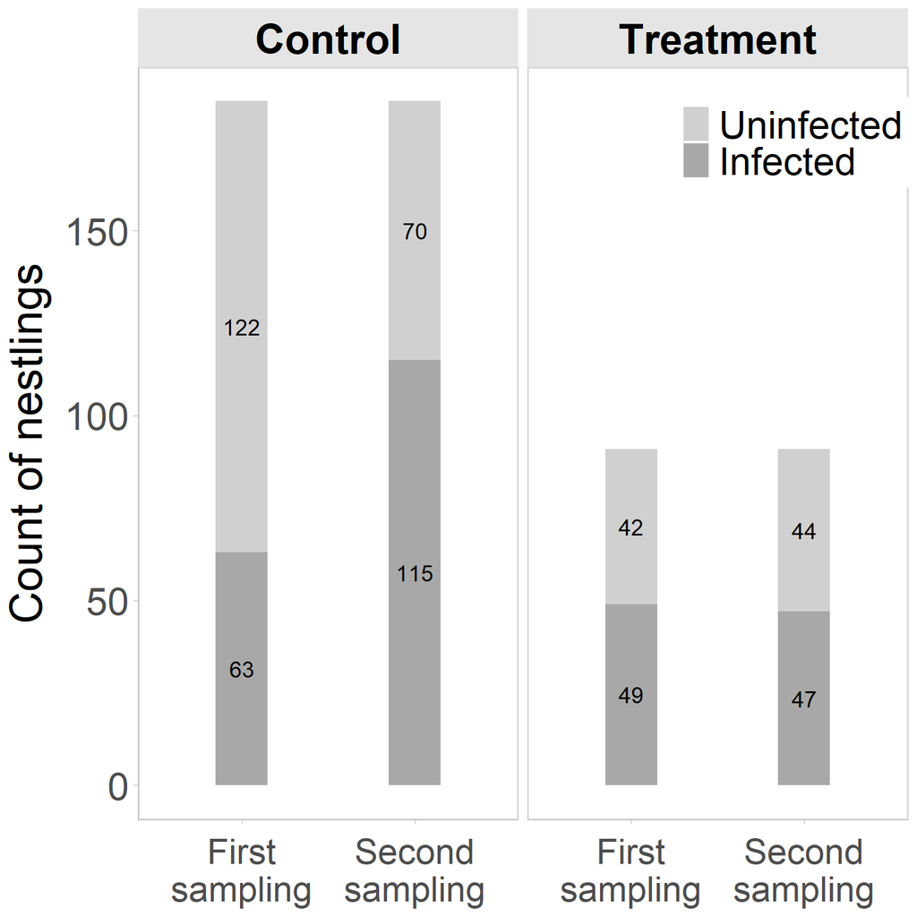

```r
## Testing for differences in age at first and second sampling
## -----------------------------------------------------------------------------
## First
t.test(df$Age_unz.1[df$Treatment %in% "Malarone"], df$Age_unz.1[df$Treatment %in%
    "Control"])

# Second

t.test(df$Age_unz[df$Treatment %in% "Malarone"], df$Age_unz[df$Treatment %in% "Control"])

## Build contingency table: Infection prevalence and treatment: First sampling
## -----------------------------------------------------------------------------
pre_treatment <- with(df, table(Prevalence1, Treatment))
prop.test(pre_treatment)
pairwise.prop.test(pre_treatment)

## Build contingency table: Infection prevalence and treatment: Second sampling
## -----------------------------------------------------------------------------
post_treatment <- with(df, table(Prevalence2, Treatment))
prop.test(post_treatment)
pairwise.prop.test(post_treatment)

## Proportion of infected individuals across time points
## -----------------------------------------------------------------------------
infected_treatment <- matrix(c(pre_treatment[2, ], post_treatment[2, ]), nrow = 2) %>%
    set_colnames(., c("First sampling", "Second sampling")) %>%
    set_rownames(., c("Control", "Malarone"))
prop.test(infected_treatment)
pairwise.prop.test(infected_treatment)

## Proportion of uninfected individuals across time points
## -----------------------------------------------------------------------------
uninfected_treatment <- matrix(c(pre_treatment[1, ], post_treatment[1, ]), nrow = 2) %>%
    set_colnames(., c("First sampling", "Second sampling")) %>%
    set_rownames(., c("Control", "Malarone"))
prop.test(uninfected_treatment)
pairwise.prop.test(uninfected_treatment)


## Plotting count of infected / uninfected nestlings across treatments
## -----------------------------------------------------------------------------
tab_cont = data.frame(Count = c(infected_treatment[1, ], uninfected_treatment[1,
    ], infected_treatment[2, ], uninfected_treatment[2, ]), Timepoint = rep(c("First sampling",
    "Second sampling"), 4), Treatment = rep(c("Control", "Treatment"), each = 4),
    Prevalence = rep(rep(c("Infected", "Uninfected"), each = 2), 2)) %>%
    mutate(Timepoint = factor(Timepoint, levels = c("First sampling", "Second sampling"))) %>%
    mutate(Prevalence = factor(Prevalence, levels = c("Uninfected", "Infected")))

## Create Figure 2a
## -----------------------------------------------------------------------------
Fig_2A <- ggplot(tab_cont) + aes(Timepoint, Count, fill = Prevalence) + facet_wrap(facets = "Treatment") +
    geom_bar(stat = "identity", width = 0.3) + labs(y = "Count of nestlings") + geom_text(aes(label = Count),
    position = position_stack(0.5), size = 5) + scale_fill_manual(values = c("#D0D0D0",
    "#A8A8A8")) + scale_x_discrete(labels = c("First\nsampling", "Second\nsampling",
    "First\nsampling", "Second\nsampling")) + theme(axis.title.x = element_blank(),
    strip.text = element_text(size = 26, face = "bold"), legend.text = element_text(size = 24),
    legend.title = element_blank(), legend.position = c(0.85, 0.9), axis.title.y = element_text(size = 28,
        margin = unit(c(0, 3, 0, 0), "mm")), axis.text.x = element_text(size = 22,
        margin = unit(c(3, 0, 0, 0), "mm")), axis.text.y = element_text(size = 24,
        margin = unit(c(0, 1, 0, 0), "mm")))

## Plotting mean infection intensity values of nestlings across treatments
## -----------------------------------------------------------------------------
mean_infint = data.frame(Sampling_rank = factor(c(rep("1", length(df$Sampling_rank)),
    as.character(df$Sampling_rank)), levels = c("1", "2"), labels = c(bquote("T"[0]),
    bquote("T"[1]))), Infection_intensity = as.numeric(c(as.character(df$Infection_intensity.1),
    as.character(df$Infection_intensity.2))), Treatment = factor(c(as.character(rep(df$Treatment,
    2))), levels = c("Control", "Malarone")))

## Figure 2b
## -----------------------------------------------------------------------------
Fig_2B <- ggplot(mean_infint) + aes(Sampling_rank, Infection_intensity, group = Treatment) +
    geom_vline(xintercept = "First sampling", linetype = "dashed", color = "darkgrey") +
    geom_vline(xintercept = "Second sampling", linetype = "dashed", color = "darkgrey") +
    labs(y = "Infection intensity (Mean +/- s.e.)") + geom_point(aes(colour = Treatment),
    position = position_jitterdodge(jitter.height = 0.1)) + stat_summary(fun = mean,
    geom = "line", size = 2, color = c("lightgrey", "black", "black", "lightgrey")) +
    scale_x_discrete(labels = c("First sampling", "Second sampling")) + stat_summary(fun = mean,
    geom = "point", size = 5) + stat_summary(fun.data = mean_se, geom = "errorbar",
    width = 0.04, size = 2) + scale_color_manual(values = c("lightgrey", "black")) +
    theme(axis.title.x = element_blank(), legend.text = element_text(size = 22),
        legend.title = element_text(size = 26), axis.title.y = element_text(size = 28,
            margin = unit(c(0, 5, 0, 0), "mm")), axis.text.x = element_text(size = 26,
            margin = unit(c(3, 0, 0, 0), "mm")), axis.text.y = element_text(size = 26,
            margin = unit(c(0, 1, 0, 3), "mm")), plot.margin = unit(c(0, 0, 0, 30),
            "pt"))

## Panel wrapping Fig2 a & b:
## -----------------------------------------------------------------------------
Fig2 <- Fig_2A + Fig_2B + plot_annotation(tag_levels = "A", tag_suffix = ")") + theme(plot.tag = element_text(size = 22,
    face = "bold"))

Fig_2A
```

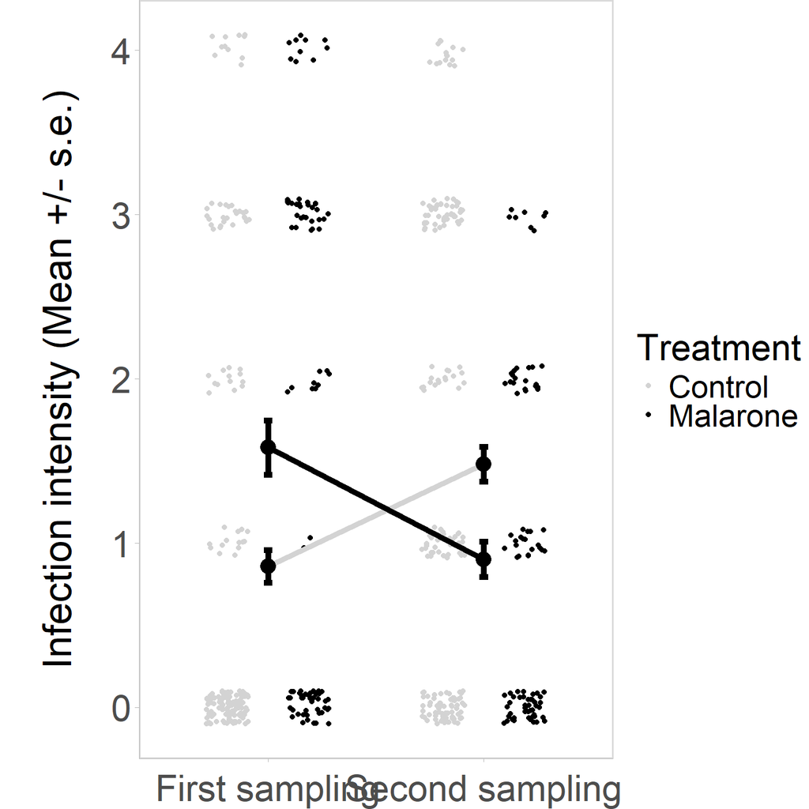

```r
Fig_2B
```

```r
ggsave(Fig2, filename = "./Figs/Fig2_efficiency_malarone.png", units = "px", width = 6000,
    height = 3000)


## Testing for difference in parasitic load between Treatment groups at first
## sampling
## -----------------------------------------------------------------------------

perm.t.test(as.numeric(as.character(df$Infection_intensity.1)) ~ df$Treatment, progress = F)

## Testing for Treatment effect on parasitemia change between first and second
## sampling Note: intensity change -100 codes for individuals that were
## uninfected throughout the experiment!
## -----------------------------------------------------------------------------
lmerTest::lmer(intensity_change ~ Treatment + Year + days_resample + (1 | Nest),
    data = df[!df$intensity_change %in% -100, ]) %>%
    summary()
```

## Infection stages as explanatory variable

Exploring differences in physiological measures that are associated with the infection stage (increase, peak or decreasing) of tested individuals. All models account for a number of fixed effects and non-independence among nest mates.

### Breathing rate

```r
## Run model
## -----------------------------------------------------------------------------
lmer_br <- lmer(Breathing_rate ~ Diff_Inf_Class + Treatment + Age_in_days + days_resample +
    Weight_g + Sex + Ambient_Temperature_AvgC + Year + (1 | Nest), data = df)

## Obtain predicted values for each infection stage
## -----------------------------------------------------------------------------
mod_br <- get_model_data(lmer_br, type = "pred", terms = "Diff_Inf_Class") %>%
    mutate(x = factor(c("Uninfected", "Increase", "Peak", "Decrease"), levels = c("Uninfected",
        "Increase", "Peak", "Decrease")))

## Extract sample size for infection stage
## -----------------------------------------------------------------------------
n <- table(df$Diff_Inf_Class[!is.na(df$Breathing_rate)])

## ad sample size as label
## -----------------------------------------------------------------------------
mod_br <- mod_br %>%
    mutate(x = factor(c(paste0(x, "\nn= ", n)), levels = c(paste0(x, "\nn= ", n))))

mod_br <- mod_br[1:4, ]

## Plotting predicted values across infection stages
## -----------------------------------------------------------------------------
Fig_S1A <-  Fig_S1A <-
ggplot(mod_br) + aes(x, predicted) + geom_hline(yintercept = mean(mod_br$predicted,
    na.rm = T), linetype = "dashed") + labs(x = "", y = bquote("Breathing rate at T"[1])) +
    ylim(c(min(mod_br$conf.low) - 1.5, max(mod_br$conf.high) + 1.5)) + geom_errorbar(aes(ymin = mod_br$conf.low,
    ymax = mod_br$conf.high), colour = "black", size = 2, width = 0.1) + geom_errorbar(aes(ymin = mod_br$predicted -
    mod_br$std.error, ymax = mod_br$predicted + mod_br$std.error), size = 8, colour = wes_palette("Zissou1",
    4), width = 0, ) + geom_point(color = "black", size = 2) + theme_classic() +
    theme(legend.position = "none", axis.title = element_text(size = 18), axis.text = element_text(size = 16),
        axis.line.x = element_blank(), axis.ticks.x = element_blank(), plot.margin = margin(0,
            0, 0, 0, "cm"), plot.title = element_text(hjust = 0.5, face = "bold")) +
    geom_segment(size = 0.8, aes(x = 1, y = max(mod_br$conf.high) + 1, xend = 4,
        yend = max(mod_br$conf.high) + 1)) + geom_text(aes(x = 2.5, y = max(mod_br$conf.high) +
    1.5), label = "n.s.", size = 5)
```

### Body temperature

```r
## Model
## -----------------------------------------------------------------------------
lmer_bt = lmer(body_temperature ~ Diff_Inf_Class + Treatment + Ambient_Temperature_AvgC +
    Age_in_days + days_resample + Weight_g + Sex + Year + (1 | Nest), data = df)

## Predicted values for each infection stage
## -----------------------------------------------------------------------------
mod_bt = get_model_data(lmer_bt, type = "pred", terms = "Diff_Inf_Class") %>%
    mutate(x = factor(c("Uninfected", "Increase", "Peak", "Decrease"), levels = c("Uninfected",
        "Increase", "Peak", "Decrease")))

# Table with sample sizes specific for body temperature data
n2 = table(df$Diff_Inf_Class[!is.na(df$body_temperature)])

mod_bt <- mod_bt %>%
    mutate(x = factor(c(paste0(x, "\nn= ", n2)), levels = c(paste0(x, "\nn= ", n2))))

mod_bt <- mod_bt[1:4, ]

# Plotting predicted values across infection stages
Fig_S1B <- ggplot(mod_bt) + aes(x, predicted) + geom_hline(yintercept = mean(mod_bt$predicted,
    na.rm = T), linetype = "dashed") + labs(x = "", y = bquote("Body temperature at T"[1])) +
    geom_errorbar(aes(ymin = mod_bt$conf.low, ymax = mod_bt$conf.high), colour = "black",
        size = 2, width = 0.1) + geom_errorbar(aes(ymin = mod_bt$predicted - mod_bt$std.error,
    ymax = mod_bt$predicted + mod_bt$std.error), size = 8, colour = wes_palette("Zissou1",
    4), width = 0) + geom_point(color = "black", outlier.shape = NA, size = 2, width = 0.3) +
    theme_classic() + theme(legend.position = "none", axis.title.y = element_text(size = 18,
    margin = unit(c(0, 3, 0, 0), "mm")), axis.text = element_text(size = 16), axis.line.x = element_blank(),
    axis.ticks.x = element_blank(), plot.margin = margin(0, 0, 0, 0, "cm"), plot.title = element_text(hjust = 0.5,
        face = "bold")) + geom_segment(size = 0.8, aes(x = 1, y = 40.6, xend = 4,
    yend = 40.6)) + geom_text(aes(x = 2.5, y = 40.7), label = "n.s.", size = 5)
```

### Body condition change

```r
## Model
## -----------------------------------------------------------------------------
lmer_bc <- lmer(delta_body_condition ~ Diff_Inf_Class + Treatment + Age_in_days +
    days_resample + Sex + Year + (1 | Nest), data = df)

# Predicted values for each infection stage
mod_bc = get_model_data(lmer_bc, type = "pred", terms = "Diff_Inf_Class") %>%
    mutate(x = factor(c("Uninfected", "Increase", "Peak", "Decrease"), levels = c("Uninfected",
        "Increase", "Peak", "Decrease")))

# Table with sample sizes specific for body condition change data
n3 = table(df$Diff_Inf_Class[!is.na(df$delta_body_condition)])

mod_bc <- mod_bc %>%
    mutate(x = factor(c(paste0(x, "\nn= ", n3)), levels = c(paste0(x, "\nn= ", n3))))


mod_bc <- mod_bc[1:4, ]

# Plotting predicted values across infection stages

Fig_S1C = ggplot(mod_bc) + aes(x, predicted) + geom_hline(yintercept = mean(mod_bc$predicted,
    na.rm = T), linetype = "dashed") + labs(x = "", y = "Δ Body condition") + geom_errorbar(aes(ymin = mod_bc$conf.low,
    ymax = mod_bc$conf.high), colour = "black", size = 2, width = 0.1) + geom_errorbar(aes(ymin = mod_bc$predicted -
    mod_bc$std.error, ymax = mod_bc$predicted + mod_bc$std.error), size = 8, colour = wes_palette("Zissou1",
    4), width = 0, ) + geom_point(color = "black", outlier.shape = NA, size = 2,
    width = 0.3) + theme_classic() + theme(legend.position = "none", axis.title = element_text(size = 18),
    axis.text = element_text(size = 16), axis.line.x = element_blank(), axis.ticks.x = element_blank(),
    plot.margin = margin(0, 0, 0, 0, "cm"), plot.title = element_text(hjust = 0.5,
        face = "bold")) + geom_segment(size = 0.8, aes(x = 1, y = max(mod_bc$conf.high) +
    17, xend = 4, yend = max(mod_bc$conf.high) + 17)) + geom_text(aes(x = 2.5, y = max(mod_bc$conf.high) +
    23), label = "n.s.", size = 5)
```

### Body condition at T1

```r
## Model
## -----------------------------------------------------------------------------
lmer_bc2 <- lmer(body_condition.2 ~ Diff_Inf_Class + Treatment + Age_in_days + days_resample +
    Sex + Year + (1 | Nest), data = df)

# Predicted values for each infection stage
mod_bc2 = get_model_data(lmer_bc2, type = "pred", terms = "Diff_Inf_Class") %>%
    mutate(x = factor(c("Uninfected", "Increase", "Peak", "Decrease"), levels = c("Uninfected",
        "Increase", "Peak", "Decrease")))

# Table with sample sizes specific for body condition change data
n3.2 = table(df$Diff_Inf_Class[!is.na(df$body_condition.2)])

mod_bc2 <- mod_bc2 %>%
    mutate(x = factor(c(paste0(x, "\nn= ", n3.2)), levels = c(paste0(x, "\nn= ",
        n3.2))))

mod_bc2 <- mod_bc2[1:4, ]

# Plotting predicted values across infection stages

Fig_S1C2 =  Fig_S1C2 =
ggplot(mod_bc2) + aes(x, predicted) + geom_hline(yintercept = mean(mod_bc2$predicted,
    na.rm = T), linetype = "dashed") + labs(x = "", y = bquote("Body condition at T"[1])) +
    geom_errorbar(aes(ymin = mod_bc2$conf.low, ymax = mod_bc2$conf.high), colour = "black",
        size = 2, width = 0.1) + geom_errorbar(aes(ymin = mod_bc2$predicted - mod_bc2$std.error,
    ymax = mod_bc2$predicted + mod_bc2$std.error), size = 8, colour = wes_palette("Zissou1",
    4), width = 0, ) + geom_point(color = "black", size = 2) + theme_classic() +
    theme(legend.position = "none", axis.title = element_text(size = 18), axis.text = element_text(size = 16),
        axis.line.x = element_blank(), axis.ticks.x = element_blank(), plot.margin = margin(0,
            0, 0, 0, "cm"), plot.title = element_text(hjust = 0.5, face = "bold")) +
    geom_segment(size = 0.8, aes(x = 1, y = max(mod_bc2$conf.high) + 17, xend = 4,
        yend = max(mod_bc2$conf.high) + 17)) + geom_text(aes(x = 2.5, y = max(mod_bc2$conf.high) +
    23), label = "n.s.", size = 5)
```

### Growth rate

```r
# Model
lmer_gr = lmer(Growth_rate ~ Diff_Inf_Class + Treatment + Sex + Age_in_days + days_resample +
    Year + (1 | Nest), data = df)

# Predicted values for each infection stages
mod_gr = get_model_data(lmer_gr, type = "pred", terms = "Diff_Inf_Class") %>%
    mutate(x = factor(c("Uninfected", "Increase", "Peak", "Decrease"), levels = c("Uninfected",
        "Increase", "Peak", "Decrease")))

# Table with sample sizes specific for growth rate data
n4 = table(df$Diff_Inf_Class[!is.na(df$Growth_rate)])

mod_gr <- mod_gr %>%
    mutate(x = factor(c(paste0(x, "\nn= ", n4)), levels = c(paste0(x, "\nn= ", n4))))

mod_gr <- mod_gr[1:4, ]

# Plotting predicted values across infection stages

Fig_S1D = ggplot(mod_gr) + aes(x, predicted) + geom_hline(yintercept = mean(mod_gr$predicted,
    na.rm = T), linetype = "dashed") + labs(x = "", y = "Growth rate") + geom_errorbar(aes(ymin = mod_gr$conf.low,
    ymax = mod_gr$conf.high), colour = "black", size = 2, width = 0.1) + geom_errorbar(aes(ymin = mod_gr$predicted -
    mod_gr$std.error, ymax = mod_gr$predicted + mod_gr$std.error), size = 8, colour = wes_palette("Zissou1",
    4), width = 0, ) + geom_point(color = "black", outlier.shape = NA, size = 2,
    width = 0.3) + theme_classic() + theme(legend.position = "none", axis.title.y = element_text(size = 18,
    margin = unit(c(0, 3, 0, 0), "mm")), axis.text = element_text(size = 16), axis.line.x = element_blank(),
    axis.ticks.x = element_blank(), plot.margin = margin(0, 0, 0, 30, "pt"), plot.title = element_text(hjust = 0.5,
        face = "bold")) + geom_segment(size = 0.8, aes(x = 1, y = max(mod_gr$conf.high) +
    1.2, xend = 4, yend = max(mod_gr$conf.high) + 1.2)) + geom_text(aes(x = 2.5,
    y = max(mod_gr$conf.high) + 2), label = "n.s.", size = 5)
```

## Summary four models

```r
# Table 1 and Table S3
# -----------------------------------------------------------------------------
sjPlot::tab_model(lmer_br, lmer_bt, lmer_bc2, lmer_gr, show.ci50 = T, show.stat = T,
    string.stat = "t", df.method = "kr", show.df = T, dv.labels = c(bquote("Breathing rate at T"[1]),
        bquote("Body temperature at T"[1]), bquote("Body condition at T"[1]), "Growth rate"),
    file = "./Tables/Table1_results_lmer_physiological_parameters_p.val_kr_Treatment2.html")
```

|  | “Breathing rate at T”[1] |  |  |  |  | “Body temperature at T”[1] |  |  |  |  | “Body condition at T”[1] |  |  |  |  | Growth rate |  |  |  |  |
| --- | --- | --- | --- | --- | --- | --- | --- | --- | --- | --- | --- | --- | --- | --- | --- | --- | --- | --- | --- | --- |
| Predictors | Estimates | CI | t | p | df | Estimates | CI | t | p | df | Estimates | CI | t | p | df | Estimates | CI | t | p | df |
| (Intercept) | 36.49 | 31.35 – 41.64 | 13.99 | **<0.001** | 174.43 | 39.78 | 39.35 – 40.21 | 181.72 | **<0.001** | 131.23 | -46.28 | -92.83 – 0.27 | -1.96 | 0.051 | 185.72 | 18.73 | 11.86 – 25.60 | 5.38 | **<0.001** | 189.64 |
| Diff Inf Class [Increase] | -0.54 | -3.00 – 1.91 | -0.44 | 0.664 | 255.75 | -0.13 | -0.48 – 0.21 | -0.78 | 0.435 | 144.80 | 1.16 | -21.22 – 23.53 | 0.10 | 0.919 | 262.63 | -0.93 | -4.36 – 2.51 | -0.53 | 0.596 | 264.83 |
| Diff Inf Class [Peak] | -1.08 | -4.80 – 2.65 | -0.57 | 0.570 | 250.56 | -0.13 | -0.58 – 0.32 | -0.58 | 0.562 | 141.73 | -21.42 | -55.19 – 12.34 | -1.25 | 0.213 | 249.15 | -2.09 | -7.32 – 3.14 | -0.79 | 0.433 | 259.48 |
| Diff Inf Class [Decrease] | -1.45 | -4.19 – 1.28 | -1.05 | 0.295 | 255.99 | 0.06 | -0.28 – 0.41 | 0.35 | 0.724 | 150.88 | -3.81 | -28.81 – 21.20 | -0.30 | 0.765 | 258.05 | -2.79 | -6.64 – 1.07 | -1.42 | 0.156 | 264.63 |
| Treatment [Malarone] | 0.08 | -2.25 – 2.40 | 0.07 | 0.948 | 255.69 | -0.04 | -0.31 – 0.23 | -0.30 | 0.761 | 133.38 | 15.81 | -5.28 – 36.90 | 1.48 | 0.141 | 252.34 | 0.72 | -2.54 – 3.98 | 0.44 | 0.663 | 262.61 |
| Age in days | 1.07 | -0.71 – 2.85 | 1.18 | 0.239 | 228.45 | 0.24 | -0.02 – 0.49 | 1.82 | 0.071 | 159.73 | 35.32 | 23.67 – 46.98 | 5.97 | **<0.001** | 253.11 | -4.72 | -6.48 – -2.96 | -5.29 | **<0.001** | 240.70 |
| days resample | -1.66 | -3.51 – 0.19 | -1.78 | 0.078 | 163.14 | -0.41 | -0.80 – -0.02 | -2.08 | **0.041** | 87.06 | -4.40 | -20.69 – 11.89 | -0.53 | 0.595 | 170.54 | 2.46 | 0.07 – 4.86 | 2.03 | **0.044** | 175.43 |
| Weight g | -2.62 | -4.20 – -1.04 | -3.27 | **0.001** | 252.27 | 0.02 | -0.21 – 0.24 | 0.17 | 0.864 | 165.24 |  |  |  |  |  |  |  |  |  |  |
| Sex [Male] | -1.53 | -3.73 – 0.67 | -1.37 | 0.171 | 253.95 | -0.08 | -0.37 – 0.21 | -0.52 | 0.607 | 152.14 | 1.61 | -14.62 – 17.85 | 0.20 | 0.845 | 240.57 | -4.30 | -6.83 – -1.78 | -3.36 | **0.001** | 252.12 |
| Ambient Temperature AvgC | -2.97 | -4.15 – -1.79 | -4.98 | **<0.001** | 126.19 | 0.55 | 0.36 – 0.74 | 5.85 | **<0.001** | 96.47 |  |  |  |  |  |  |  |  |  |  |
| Year [2018] | -5.83 | -11.57 – -0.10 | -2.01 | **0.046** | 156.25 |  |  |  |  |  | 72.62 | 20.64 – 124.60 | 2.76 | **0.006** | 166.88 | 4.53 | -3.10 – 12.15 | 1.17 | 0.243 | 170.61 |
| Year [2019] | -5.08 | -10.82 – 0.66 | -1.75 | 0.082 | 154.17 |  |  |  |  |  | 84.76 | 32.96 – 136.55 | 3.23 | **0.001** | 159.71 | 1.94 | -5.64 – 9.52 | 0.51 | 0.614 | 163.03 |
| Year [2020] | -6.40 | -12.18 – -0.63 | -2.19 | **0.030** | 156.03 | 0.44 | 0.02 – 0.86 | 2.11 | **0.038** | 73.71 | 102.86 | 52.00 – 153.72 | 3.99 | **<0.001** | 164.13 | 6.70 | -0.75 – 14.15 | 1.77 | 0.078 | 167.64 |
| Random Effects |  |  |  |  |  |  |  |  |  |  |  |  |  |  |  |  |  |  |  |  |
| σ<sup>2</sup> | 42.40 |  |  |  |  | 0.35 |  |  |  |  | 3196.18 |  |  |  |  | 83.62 |  |  |  |  |
| τ<sub>00</sub> | 15.28 <sub>Nest</sub> |  |  |  |  | 0.50 <sub>Nest</sub> |  |  |  |  | 2037.62 <sub>Nest</sub> |  |  |  |  | 33.58 <sub>Nest</sub> |  |  |  |  |
| ICC | 0.26 |  |  |  |  | 0.59 |  |  |  |  | 0.39 |  |  |  |  | 0.29 |  |  |  |  |
| N | 135 <sub>Nest</sub> |  |  |  |  | 77 <sub>Nest</sub> |  |  |  |  | 139 <sub>Nest</sub> |  |  |  |  | 139 <sub>Nest</sub> |  |  |  |  |
| Observations | 269 |  |  |  |  | 178 |  |  |  |  | 276 |  |  |  |  | 276 |  |  |  |  |
| Marginal R<sup>2</sup> / Conditional R<sup>2</sup> | 0.180 / 0.397 |  |  |  |  | 0.303 / 0.712 |  |  |  |  | 0.230 / 0.530 |  |  |  |  | 0.232 / 0.452 |  |  |  |  |

## Parasitemia as explanatory variable

Exploration of effects by parasitemia levels on physiology of individuals. All models account for a number of fixed effects and non-independence among nest mates.

### Breathing rate

```r
## Model:
## Note:
## One Contrast for the Interaction of Infection intensity and treatment
## is not estimatable due to the lack of infection level 4 for the Malarone-group
## -----------------------------------------------------------------------------
lmer_br_para = lmer(
  Breathing_rate ~ Infection_intensity.2 + Treatment + Age_in_days + days_resample +
    Weight_g + Sex + Ambient_Temperature_AvgC + Year + (1|Nest), data = df)

## Rerun without intercept for plotting mean estimates
## -----------------------------------------------------------------------------
lmer_br_para_no_intercept = lmer(
  Breathing_rate ~ 0 + Infection_intensity.2 + Treatment + Age_in_days + days_resample +
    Weight_g + Sex + Ambient_Temperature_AvgC + Year + (1|Nest), data = df)

## Obtain effect sizes for post-treatment parasitemia and derive model predictions
## -----------------------------------------------------------------------------
mod_br_para <-
  left_join(plot_model(lmer_br_para_no_intercept, se = F, )[["data"]][1:5,], ## 95% CI
            plot_model(lmer_br_para_no_intercept, se = T, )[["data"]][1:5,]) %>%  ## SE
  mutate(predicted = estimate) %>%
  mutate(lower_CI = conf.low) %>%
  mutate(higher_CI = conf.high) %>%
  mutate(se = std.error) %>%
  mutate(x = factor(c("0","1","2","3","4"), levels = c("0","1","2","3","4")))


## Obtain sample sizes for labels
## -----------------------------------------------------------------------------
m1 = table(df$Infection_intensity.2[!is.na(df$Breathing_rate)])
mod_br_para <- mod_br_para %>%
  mutate(x = factor(c(paste0(x,"\nn= ",m1)), levels = c(paste0(x,"\nn= ",m1))))

# Plotting predicted values across infection intensities
## -----------------------------------------------------------------------------
Fig_4A = ggplot(mod_br_para) +
  aes(as.factor(mod_br_para$x),mod_br_para$predicted) +
  geom_hline(yintercept = mean(mod_br_para$predicted, na.rm = T), linetype = "dashed") +
  labs(x = "", y = bquote("Breathing rate at T"[1])) +
  geom_errorbar(aes(ymin = mod_br_para$lower_CI,
                    ymax = mod_br_para$higher_CI),colour = "black",size = 2, width = .1) +
  geom_errorbar(aes(ymin = mod_br_para$predicted - mod_br_para$se,
                    ymax = mod_br_para$predicted + mod_br_para$se),
                size = 8, colour = wes_palette("Zissou1",5), width = 0,) +
  geom_point(color = "black", size = 4) +
  theme_classic() +
  theme(legend.position = "none",
        axis.title = element_text(size = 20),
        axis.text = element_text(size = 16),
        axis.line.x = element_blank(),
        axis.ticks.x = element_blank(), plot.margin = margin(0, 0, 0, 0, "cm"),
        plot.title = element_text(hjust = 0.5, face = "bold")) +
  geom_segment(size = .8, aes(x = 1, y = max(mod_br_para$higher_CI, na.rm = T) + 1.2,
                              xend = 5, yend = max(mod_br_para$higher_CI, na.rm = T) + 1.2)) +
    geom_text(aes(x = 3, y = max(mod_br_para$higher_CI, na.rm = T) + 2),
              label = "P = 0.15", size = 6)
```

### Body temperature

```r
## Model:
## Note:
## One Contrast for the Interaction of Infection intensity and treatment
## is not estimatable due to the lack of infection level 4 for the Malarone-group
## -----------------------------------------------------------------------------
lmer_bt_para = lmer(
  body_temperature ~ Infection_intensity.2 + Treatment + Age_in_days + days_resample +
    Ambient_Temperature_AvgC + Weight_g + Sex + Year + (1|Nest), data = df)

## Rerun without intercept for plotting mean estimates
## -----------------------------------------------------------------------------
lmer_bt_para_no_intercept = lmer(
  body_temperature ~ 0 + Infection_intensity.2 + Treatment + days_resample +
    Ambient_Temperature_AvgC + Age_in_days + Weight_g + Sex + Year + (1|Nest), data = df)

## Obtain effect sizes for post-treatment parasitemia and derive model predictions
## -----------------------------------------------------------------------------
mod_bt_para <-
  left_join(plot_model(lmer_bt_para_no_intercept, se = F, )[["data"]][1:5,], ## 95% CI
            plot_model(lmer_bt_para_no_intercept, se = T, )[["data"]][1:5,]) %>%  ## SE
  mutate(predicted = estimate) %>%
  mutate(lower_CI = conf.low) %>%
  mutate(higher_CI = conf.high) %>%
  mutate(se = std.error) %>%
  mutate(x = factor(c("0","1","2","3","4"), levels = c("0","1","2","3","4")))

## Obtain sample sizes for labels
## -----------------------------------------------------------------------------
m2 = table(df$Infection_intensity.2[!is.na(df$body_temperature)])
mod_bt_para <- mod_bt_para %>%
  mutate(x = factor(c(paste0(x,"\nn= ",m2)), levels = c(paste0(x,"\nn= ",m2))))

## Plotting predicted values across infection intensities
## -----------------------------------------------------------------------------
Fig_4B = ggplot(mod_bt_para) +
  aes(as.factor(mod_bt_para$x),mod_bt_para$predicted) +
  geom_hline(yintercept = mean(mod_bt_para$predicted, na.rm = T), linetype = "dashed") +
  geom_errorbar(aes(ymin = mod_bt_para$lower_CI,ymax = mod_bt_para$higher_CI),colour = "black",size = 2, width = .1) +
  geom_errorbar(aes(ymin = mod_bt_para$predicted - mod_bt_para$se,ymax = mod_bt_para$predicted + mod_bt_para$se),
                size = 8,colour = wes_palette("Zissou1",5), width = 0,) +
  labs(x = "", y = bquote("Body temperature at T"[1])) +
  geom_point(color = "black", size = 4) +
  theme_classic() +
  theme(legend.position = "none",
        axis.title = element_text(size = 20),
        axis.text = element_text(size = 16),
        axis.line.x = element_blank(),
        axis.ticks.x = element_blank(), plot.margin = margin(0, 0, 0, 0, "cm"),
        plot.title = element_text(hjust = 0.5, face = "bold")) +
  geom_segment(size = .8, aes(x = 1, y = max(mod_bt_para$higher_CI, na.rm = T) + 0.2,
                              xend = 5, yend = max(mod_bt_para$higher_CI, na.rm = T) + 0.2)) +
  geom_text(aes(x = 3, y = max(mod_bt_para$higher_CI, na.rm = T) + 0.3),
            label = "P = 0.006", size = 5) +
  geom_segment(size = .8,
               aes(x = 1, y = max(mod_bt_para$higher_CI, na.rm = T) + 0.2,
                   xend = 1, yend = max(mod_bt_para$higher_CI, na.rm = T) + 0.1)) +
  geom_segment(size = .8,
               aes(x = 5, y = max(mod_bt_para$higher_CI, na.rm = T) + 0.1,
                   xend = 5, yend = max(mod_bt_para$higher_CI, na.rm = T) + 0.2))
```

### Body condition change

```r
## Model:
## Note:
## One Contrast for the Interaction of Infection intensity and treatment
## is not estimatable due to the lack of infection level 4 for the Malarone-group
## -----------------------------------------------------------------------------
lmer_bc_para <- lmer(
  delta_body_condition ~ Infection_intensity.2 + Treatment + Age_in_days + days_resample +
    Sex + Year + (1|Nest), data = df)

## Rerun without intercept for plotting mean estimates
## -----------------------------------------------------------------------------
lmer_bc_para_no_intercept <- lmer(
  delta_body_condition ~ 0+ Infection_intensity.2 + Treatment + Age_in_days + days_resample +
    Sex + Year + (1|Nest), data = df)

## Obtain effect sizes for post-treatment parasitemia and derive model predictions
## -----------------------------------------------------------------------------
mod_bc_para <-
  left_join(plot_model(lmer_bc_para_no_intercept, se = F, )[["data"]][1:5,], ## 95% CI
            plot_model(lmer_bc_para_no_intercept, se = T, )[["data"]][1:5,]) %>%  ## SE
  mutate(predicted = estimate) %>%
  mutate(lower_CI = conf.low) %>%
  mutate(higher_CI = conf.high) %>%
  mutate(se = std.error) %>%
  mutate(x = factor(c("0","1","2","3","4"), levels = c("0","1","2","3","4")))

# Table with sample sizes specific for body condition change data
m3 = table(df$Infection_intensity.2[!is.na(df$delta_body_condition)])
mod_bc_para <- mod_bc_para %>%
  mutate(x = factor(c(paste0(x,"\nn= ",m3)), levels = c(paste0(x,"\nn= ",m3))))

# Plotting predicted values across infection intensities

Fig_4C = ggplot(mod_bc_para) +
  aes(as.factor(mod_bc_para$x),mod_bc_para$predicted) +
  geom_hline(yintercept = mean(mod_bc_para$predicted, na.rm = T), linetype = "dashed") +
  labs(x = bquote("Parasitemia at T"[1]), y = "Δ Body condition") +
  geom_errorbar(aes(ymin = mod_bc_para$lower_CI, ymax = mod_bc_para$higher_CI),
                colour = "black",size = 2, width = .1) +
  geom_errorbar(aes(ymin = mod_bc_para$predicted - mod_bc_para$se,
                    ymax = mod_bc_para$predicted + mod_bc_para$se),
                size = 8, colour = wes_palette("Zissou1",5), width = 0,) +
  geom_point(color = "black", size = 4) +
  theme_classic() +
  theme(legend.position = "none",
        axis.title = element_text(size = 20),
        axis.title.x = element_text(size = 20, vjust=-0.5),
        axis.text = element_text(size = 16),
        axis.line.x = element_blank(),
        axis.ticks.x = element_blank(), plot.margin = margin(0, 0, 0, 0, "cm"),
        plot.title = element_text(hjust = 0.5, face = "bold")) +
  geom_segment(size = .8,
                 aes(x = 1, y = 60, xend = 5, yend = 60)) +
    geom_text(aes(x = 3, y = 67),
              label = "P = 0.067", size = 5) +
  geom_segment(size = .8,
                 aes(x = 1, y = 60, xend = 1, yend = 53)) +
  geom_segment(size = .8,
                 aes(x = 5, y = 60, xend = 5, yend = 53))
```

### Body condition at T1

```r
## Model:
## Note:
## One Contrast for the Interaction of Infection intensity and treatment
## is not estimatable due to the lack of infection level 4 for the Malarone-group
## -----------------------------------------------------------------------------
lmer_bc_para2 <- lmer(
  body_condition.2 ~ Infection_intensity.2 + Treatment + Age_in_days + days_resample +
    Sex + Year + (1|Nest), data = df)

## Rerun without intercept for plotting mean estimates
## -----------------------------------------------------------------------------
lmer_bc_para_no_intercept2 <- lmer(
  body_condition.2 ~ 0+ Infection_intensity.2 + Treatment + Age_in_days + days_resample +
    Sex + Year + (1|Nest), data = df)

## Obtain effect sizes for post-treatment parasitemia and derive model predictions
## -----------------------------------------------------------------------------
mod_bc_para2 <-
  left_join(plot_model(lmer_bc_para_no_intercept2, se = F, )[["data"]][1:5,], ## 95% CI
            plot_model(lmer_bc_para_no_intercept2, se = T, )[["data"]][1:5,]) %>%  ## SE
  mutate(predicted = estimate) %>%
  mutate(lower_CI = conf.low) %>%
  mutate(higher_CI = conf.high) %>%
  mutate(se = std.error) %>%
  mutate(x = factor(c("0","1","2","3","4"), levels = c("0","1","2","3","4")))

# Table with sample sizes specific for body condition change data
m3.2 = table(df$Infection_intensity.2[!is.na(df$body_condition.2)])

mod_bc_para2 <- mod_bc_para2 %>%
  mutate(x = factor(c(paste0(x,"\nn= ",m3.2)), levels = c(paste0(x,"\nn= ",m3.2))))

# Plotting predicted values across infection intensities

Fig_4C2 = ggplot(mod_bc_para2) +
  aes(as.factor(mod_bc_para2$x),
      mod_bc_para2$predicted) +
  geom_hline(yintercept = mean(mod_bc_para2$predicted, na.rm = T),
             linetype = "dashed") +
  labs(x = bquote("Parasitemia at T"[1]),
       y = bquote("Body condition at T"[1])) +
  geom_errorbar(aes(ymin = mod_bc_para2$lower_CI,
                    ymax = mod_bc_para2$higher_CI),
                colour = "black",
                size = 2,
                width = .1) +
  geom_errorbar(aes(ymin = mod_bc_para2$predicted - mod_bc_para2$se,
                    ymax = mod_bc_para2$predicted + mod_bc_para2$se),
                size = 8,
                colour = wes_palette("Zissou1",5),
                width = 0,) +
  geom_point(color = "black",
             size = 4) +
  theme_classic() +
  theme(legend.position = "none",
        axis.title = element_text(size = 20),
        axis.title.x = element_text(size = 20,
                                    vjust=-0.5),
        axis.text = element_text(size = 16),
        axis.line.x = element_blank(),
        axis.ticks.x = element_blank(),
        plot.margin = margin(0, 0, 0, 0, "cm"),
        plot.title = element_text(hjust = 0.5,
                                  face = "bold")) +
  geom_segment(size = .8,
                 aes(x = 1, y = 60, xend = 5, yend = 60)) +
    geom_text(aes(x = 3, y = 67),
              label = "P = 0.026", size = 5) +
  geom_segment(size = .8,
                 aes(x = 1, y = 60, xend = 1, yend = 53)) +
  geom_segment(size = .8,
                 aes(x = 5, y = 60, xend = 5, yend = 53))
```

### Growth rate

```r
## Model:
## Note:
## One Contrast for the Interaction of Infection intensity and treatment
## is not estimatable due to the lack of infection level 4 for the Malarone-group
## -----------------------------------------------------------------------------
lmer_gr_para = lmer(
  Growth_rate ~ Infection_intensity.2 + Treatment +
   Age_in_days + days_resample + Sex +  Year + (1 | Nest), data = df)

## Rerun without intercept for plotting mean estimates
## -----------------------------------------------------------------------------
lmer_gr_para_no_intercept  = lmer(
  Growth_rate ~ 0 + Infection_intensity.2 + Treatment +
    Age_in_days + days_resample + Sex +  Year + (1 | Nest), data = df)

## Obtain effect sizes for post-treatment parasitemia and derive model predictions
## -----------------------------------------------------------------------------
mod_gr_para <-
  left_join(plot_model(lmer_gr_para_no_intercept, se = F, )[["data"]][1:5,], ## 95% CI
            plot_model(lmer_gr_para_no_intercept, se = T, )[["data"]][1:5,]) %>%  ## SE
  mutate(predicted = estimate) %>%
  mutate(lower_CI = conf.low) %>%
  mutate(higher_CI = conf.high) %>%
  mutate(se = std.error) %>%
  mutate(x = factor(c("0","1","2","3","4"), levels = c("0","1","2","3","4")))

# Table with sample sizes specific for growth rate data
m4 = table(df$Infection_intensity.2[!is.na(df$Growth_rate)])

mod_gr_para <- mod_gr_para %>%
  mutate(x = factor(c(paste0(x,"\nn= ",m4)), levels = c(paste0(x,"\nn= ",m4))))

# Plotting predicted values across infection intensities
## -----------------------------------------------------------------------------
Fig_4D = ggplot(mod_gr_para) +
  aes(as.factor(mod_gr_para$x),mod_gr_para$predicted) +
  geom_hline(yintercept = mean(mod_gr_para$predicted, na.rm = T), linetype = "dashed") +
  labs(x = bquote("Parasitemia at T"[1]), y = "Growth rate") +
  geom_errorbar(aes(ymin = mod_gr_para$lower_CI,
                    ymax = mod_gr_para$higher_CI), colour = "black",size = 2, width = .1) +
  geom_errorbar(aes(ymin = mod_gr_para$predicted - mod_gr_para$se,
                    ymax = mod_gr_para$predicted + mod_gr_para$se),size = 8,
                colour = wes_palette("Zissou1",5), width = 0) +
  geom_point(color = "black", outlier.shape = NA, size = 4, width = .3) +
  theme_classic() +
  theme(legend.position = "none",
        axis.title = element_text(size = 20),
        axis.title.x = element_text(size = 20, vjust=-0.5),
        axis.text = element_text(size = 16),
        axis.line.x = element_blank(),
        axis.ticks.x = element_blank(), plot.margin = margin(0, 0, 0, 0, "cm"),
        plot.title = element_text(hjust = 0.5, face = "bold")) +
  geom_segment(size = .8,
               aes(x = 1, y = 30, xend = 5, yend = 30)) +
  geom_text(aes(x = 3, y = 31),
            label = "P = 0.087", size = 5) +
  geom_segment(size = .8,
               aes(x = 1, y = 29, xend = 1, yend = 30)) +
  geom_segment(size = .8,
               aes(x = 5, y = 29, xend = 5, yend = 30))
```

### Summary four models

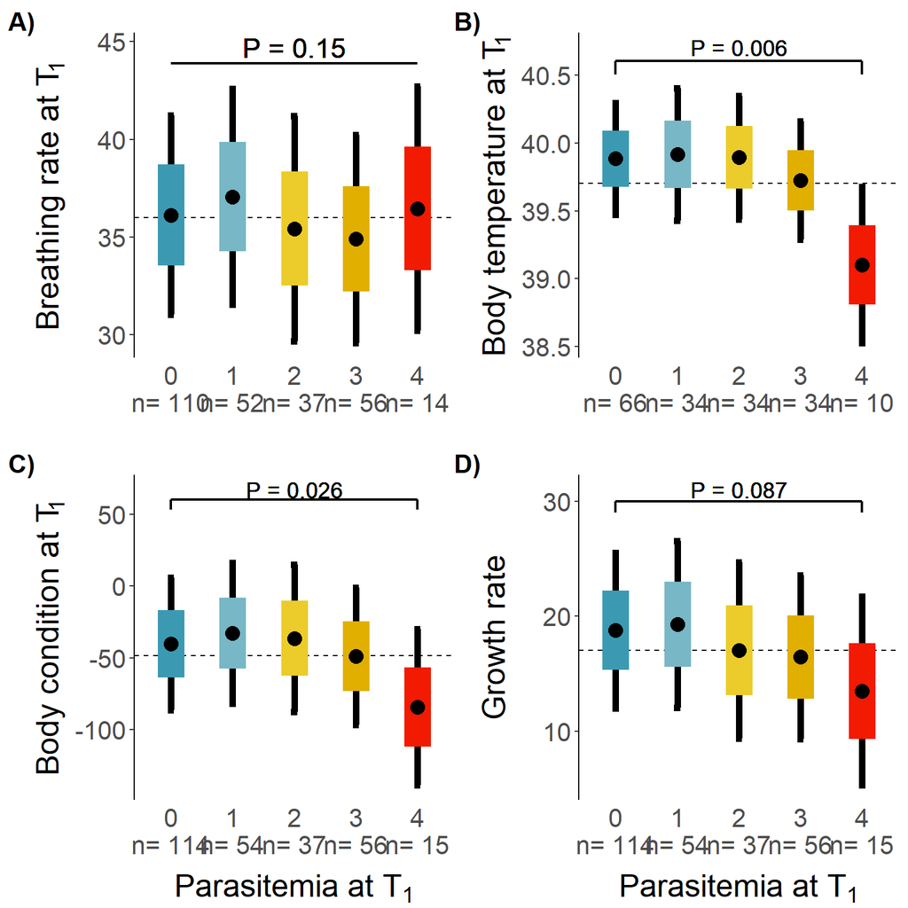

```r
## Create multipanel Figure 4
## -----------------------------------------------------------------------------
fig4 = Fig_4A + Fig_4B + Fig_4C2 + Fig_4D + plot_annotation(tag_levels = "A", tag_suffix = ")") &
    theme(plot.tag = element_text(size = 16, face = "bold"))
fig4
```

```r
ggsave(fig4, filename = "./Figs/Fig4_predicted_physio_param_infection_intensities.png",
    units = "px", width = 3700, height = 3700)

## Table 2
## -----------------------------------------------------------------------------
sjPlot::tab_model(lmer_br_para, lmer_bt_para, lmer_bc_para2, lmer_gr_para, show.ci50 = T,
    show.df = T, show.stat = T, string.stat = "t", p.val = "kr", dv.labels = c(bquote("Breathing rate at T"[1]),
        bquote("Body temperature at T"[1]), bquote("Body condition at T"[1]), "Growth rate"),
    file = "./Tables/Table2_results_parasitemia_lmer_physiological_parameters_p.val_kr_Treatment2.html")
```

|  | “Breathing rate at T”[1] |  |  |  |  | “Body temperature at T”[1] |  |  |  |  | “Body condition at T”[1] |  |  |  |  | Growth rate |  |  |  |  |
| --- | --- | --- | --- | --- | --- | --- | --- | --- | --- | --- | --- | --- | --- | --- | --- | --- | --- | --- | --- | --- |
| Predictors | Estimates | CI | t | p | df | Estimates | CI | t | p | df | Estimates | CI | t | p | df | Estimates | CI | t | p | df |
| (Intercept) | 36.13 | 31.01 – 41.25 | 13.93 | **<0.001** | 167.51 | 39.88 | 39.47 – 40.30 | 190.38 | **<0.001** | 129.04 | -40.16 | -86.25 – 5.93 | -1.72 | 0.087 | 179.05 | 18.77 | 11.97 – 25.57 | 5.45 | **<0.001** | 182.45 |
| Infection intensity 2 [1] | 0.93 | -1.71 – 3.58 | 0.69 | 0.488 | 251.01 | 0.03 | -0.30 – 0.37 | 0.19 | 0.851 | 141.70 | 7.36 | -16.29 – 31.01 | 0.61 | 0.540 | 247.56 | 0.53 | -3.15 – 4.21 | 0.28 | 0.777 | 258.65 |
| Infection intensity 2 [2] | -0.70 | -3.63 – 2.24 | -0.47 | 0.640 | 250.24 | 0.01 | -0.32 – 0.34 | 0.06 | 0.952 | 147.11 | 3.87 | -22.53 – 30.26 | 0.29 | 0.773 | 246.49 | -1.74 | -5.85 – 2.37 | -0.83 | 0.405 | 257.89 |
| Infection intensity 2 [3] | -1.22 | -3.88 – 1.44 | -0.90 | 0.367 | 253.81 | -0.16 | -0.53 – 0.21 | -0.85 | 0.398 | 151.18 | -8.59 | -32.88 – 15.71 | -0.70 | 0.487 | 263.50 | -2.32 | -6.05 – 1.42 | -1.22 | 0.223 | 263.04 |
| Infection intensity 2 [4] | 0.33 | -4.09 – 4.75 | 0.15 | 0.882 | 253.42 | -0.78 | -1.34 – -0.23 | -2.79 | **0.006** | 149.31 | -43.99 | -82.92 – -5.05 | -2.22 | **0.027** | 257.63 | -5.26 | -11.29 – 0.76 | -1.72 | 0.087 | 262.85 |
| Treatment [Malarone] | -0.38 | -2.69 – 1.93 | -0.32 | 0.748 | 252.55 | -0.09 | -0.37 – 0.18 | -0.65 | 0.516 | 141.76 | 10.20 | -10.82 – 31.22 | 0.96 | 0.340 | 261.27 | -0.45 | -3.69 – 2.79 | -0.28 | 0.783 | 263.54 |
| Age in days | 0.99 | -0.77 – 2.74 | 1.11 | 0.268 | 222.72 | 0.26 | 0.01 – 0.50 | 2.06 | **0.041** | 154.25 | 33.32 | 21.92 – 44.71 | 5.76 | **<0.001** | 245.87 | -5.03 | -6.75 – -3.32 | -5.78 | **<0.001** | 231.03 |
| days resample | -1.75 | -3.60 – 0.11 | -1.86 | 0.065 | 155.97 | -0.46 | -0.84 – -0.08 | -2.40 | **0.019** | 88.06 | -4.59 | -20.72 – 11.54 | -0.56 | 0.575 | 163.67 | 2.55 | 0.19 – 4.92 | 2.13 | **0.035** | 167.37 |
| Weight g | -2.65 | -4.23 – -1.07 | -3.30 | **0.001** | 251.04 | -0.03 | -0.25 – 0.19 | -0.24 | 0.813 | 165.44 |  |  |  |  |  |  |  |  |  |  |
| Sex [Male] | -1.57 | -3.77 – 0.63 | -1.41 | 0.160 | 253.17 | -0.12 | -0.40 – 0.17 | -0.82 | 0.416 | 155.52 | 1.88 | -14.20 – 17.96 | 0.23 | 0.818 | 235.93 | -4.10 | -6.62 – -1.58 | -3.21 | **0.002** | 249.50 |
| Ambient Temperature AvgC | -2.91 | -4.10 – -1.72 | -4.86 | **<0.001** | 126.50 | 0.55 | 0.36 – 0.73 | 5.95 | **<0.001** | 93.81 |  |  |  |  |  |  |  |  |  |  |
| Year [2018] | -5.62 | -11.37 – 0.12 | -1.93 | 0.055 | 154.43 |  |  |  |  |  | 67.49 | 15.55 – 119.42 | 2.57 | **0.011** | 165.30 | 4.45 | -3.17 – 12.07 | 1.15 | 0.250 | 168.75 |
| Year [2019] | -4.96 | -10.71 – 0.79 | -1.70 | 0.091 | 153.54 |  |  |  |  |  | 82.74 | 31.11 – 134.37 | 3.17 | **0.002** | 158.66 | 2.28 | -5.27 – 9.84 | 0.60 | 0.551 | 161.89 |
| Year [2020] | -6.50 | -12.29 – -0.70 | -2.21 | **0.028** | 156.35 | 0.38 | -0.02 – 0.79 | 1.87 | 0.065 | 75.49 | 95.24 | 44.37 – 146.10 | 3.70 | **<0.001** | 164.05 | 6.35 | -1.12 – 13.81 | 1.68 | 0.095 | 167.52 |
| Random Effects |  |  |  |  |  |  |  |  |  |  |  |  |  |  |  |  |  |  |  |  |
| σ<sup>2</sup> | 42.25 |  |  |  |  | 0.35 |  |  |  |  | 3135.80 |  |  |  |  | 83.20 |  |  |  |  |
| τ<sub>00</sub> | 15.43 <sub>Nest</sub> |  |  |  |  | 0.45 <sub>Nest</sub> |  |  |  |  | 2047.05 <sub>Nest</sub> |  |  |  |  | 33.30 <sub>Nest</sub> |  |  |  |  |
| ICC | 0.27 |  |  |  |  | 0.57 |  |  |  |  | 0.39 |  |  |  |  | 0.29 |  |  |  |  |
| N | 135 <sub>Nest</sub> |  |  |  |  | 77 <sub>Nest</sub> |  |  |  |  | 139 <sub>Nest</sub> |  |  |  |  | 139 <sub>Nest</sub> |  |  |  |  |
| Observations | 269 |  |  |  |  | 178 |  |  |  |  | 276 |  |  |  |  | 276 |  |  |  |  |
| Marginal R<sup>2</sup> / Conditional R<sup>2</sup> | 0.184 / 0.402 |  |  |  |  | 0.329 / 0.709 |  |  |  |  | 0.238 / 0.539 |  |  |  |  | 0.241 / 0.458 |  |  |  |  |

## Host health to parasitemia

```r
# Results presented in Table 2

## Infection intensity as numerical variable
## -----------------------------------------------------------------------------
tol_resdata <- df %>%
    mutate(Infection_intensity.2 = as.numeric(Infection_intensity.2)) %>%
    mutate(Diff_Inf_Class = factor(Diff_Inf_Class, levels = c("Increase", "Peak",
        "Decrease")))

## Modeling host health to Infection intensity
## -----------------------------------------------------------------------------
lm(delta_body_condition ~ Infection_intensity.2, data = tol_resdata) %>%
    summary()
```

```
#>
#> Call:
#> lm(formula = delta_body_condition ~ Infection_intensity.2, data = tol_resdata)
#>
#> Residuals:
#>     Min      1Q  Median      3Q     Max
#> -211.65  -39.50    1.55   40.02  326.10
#>
#> Coefficients:
#>                       Estimate Std. Error t value Pr(>|t|)
#> (Intercept)             34.931      8.368   4.174 4.02e-05 ***
#> Infection_intensity.2   -7.017      3.161  -2.220   0.0273 *
#> ---
#> Signif. codes:  0 '***' 0.001 '**' 0.01 '*' 0.05 '.' 0.1 ' ' 1
#>
#> Residual standard error: 69.75 on 274 degrees of freedom
#> Multiple R-squared:  0.01766,    Adjusted R-squared:  0.01408
#> F-statistic: 4.927 on 1 and 274 DF,  p-value: 0.02726
## Modeling host health to Infection intensity : Infection stages
## -----------------------------------------------------------------------------
```

```r
tolres_deltamod = lm(delta_body_condition ~ Infection_intensity.2 * Diff_Inf_Class,
    data = tol_resdata)
summary(tolres_deltamod)
```

```
#>
#> Call:
#> lm(formula = delta_body_condition ~ Infection_intensity.2 * Diff_Inf_Class,
#>     data = tol_resdata)
#>
#> Residuals:
#>      Min       1Q   Median       3Q      Max
#> -166.272  -38.524   -1.111   46.165  149.603
#>
#> Coefficients:
#>                                              Estimate Std. Error t value
#> (Intercept)                                   101.357     20.460   4.954
#> Infection_intensity.2                         -24.078      5.994  -4.017
#> Diff_Inf_ClassPeak                             72.296     95.983   0.753
#> Diff_Inf_ClassDecrease                        -80.769     27.280  -2.961
#> Infection_intensity.2:Diff_Inf_ClassPeak      -17.724     24.228  -0.732
#> Infection_intensity.2:Diff_Inf_ClassDecrease   20.491      9.614   2.131
#>                                              Pr(>|t|)
#> (Intercept)                                  1.69e-06 ***
#> Infection_intensity.2                        8.69e-05 ***
#> Diff_Inf_ClassPeak                            0.45232
#> Diff_Inf_ClassDecrease                        0.00349 **
#> Infection_intensity.2:Diff_Inf_ClassPeak      0.46540
#> Infection_intensity.2:Diff_Inf_ClassDecrease  0.03444 *
#> ---
#> Signif. codes:  0 '***' 0.001 '**' 0.01 '*' 0.05 '.' 0.1 ' ' 1
#>
#> Residual standard error: 61.92 on 177 degrees of freedom
#>   (93 observations deleted due to missingness)
#> Multiple R-squared:  0.1074, Adjusted R-squared:  0.08218
#> F-statistic: 4.259 on 5 and 177 DF,  p-value: 0.001109
## Comparison of intercepts
## -----------------------------------------------------------------------------
```

```r
emm = emmeans(tolres_deltamod, "Diff_Inf_Class", at = list(Infection_intensity.2 = 0))
pairs(emm)
```

```
#>  contrast            estimate   SE  df t.ratio p.value
#>  Increase - Peak        -72.3 96.0 177  -0.753  0.7321
#>  Increase - Decrease     80.8 27.3 177   2.961  0.0097
#>  Peak - Decrease        153.1 95.5 177   1.603  0.2471
#>
#> P value adjustment: tukey method for comparing a family of 3 estimates
## Pairwise comparison of slopes
## -----------------------------------------------------------------------------
```

```r
lms_delta = lstrends(tolres_deltamod, ~Diff_Inf_Class:Infection_intensity.2, var = "Infection_intensity.2")
contrast(lms_delta, "pairwise")
```

```
#>  contrast
#>  Increase Infection_intensity.22.94535519125683 - Peak Infection_intensity.22.94535519125683
#>  Increase Infection_intensity.22.94535519125683 - Decrease Infection_intensity.22.94535519125683
#>  Peak Infection_intensity.22.94535519125683 - Decrease Infection_intensity.22.94535519125683
#>  estimate    SE  df t.ratio p.value
#>      17.7 24.20 177   0.732  0.7451
#>     -20.5  9.61 177  -2.131  0.0865
#>     -38.2 24.60 177  -1.550  0.2701
#>
#> P value adjustment: tukey method for comparing a family of 3 estimates
## Comparison of slopes to zero
## -----------------------------------------------------------------------------
```

```r
summary(lms_delta, infer = T)
```

```
#>  Diff_Inf_Class Infection_intensity.2 Infection_intensity.2.trend    SE  df
#>  Increase                        2.95                      -24.08  5.99 177
#>  Peak                            2.95                      -41.80 23.50 177
#>  Decrease                        2.95                       -3.59  7.52 177
#>  lower.CL upper.CL t.ratio p.value
#>     -35.9   -12.25  -4.017  0.0001
#>     -88.1     4.52  -1.781  0.0767
#>     -18.4    11.25  -0.477  0.6339
#>
#> Confidence level used: 0.95
## Plotting body condition change with the interaction second infection
## intensity - infection stage
## -----------------------------------------------------------------------------
```

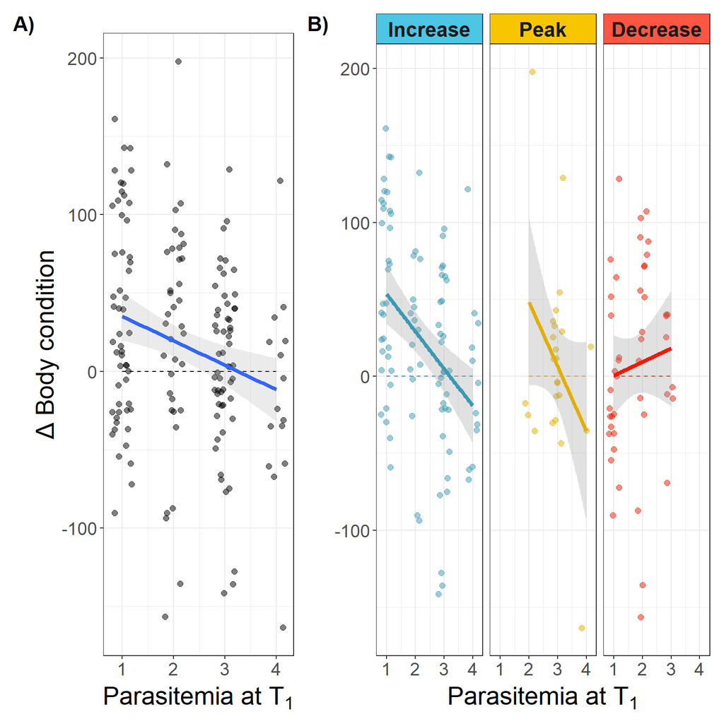

```r
tolres <- ggplot(data = filter(df, !Infection_intensity.2 %in% c(NA, 0), !Diff_Inf_Class %in%
    NA), aes(y = delta_body_condition, x = as.numeric(Infection_intensity.2))) +
    geom_jitter(size = 2, alpha = 0.5, width = 0.2) + geom_line(y = 0, linetype = "dashed") +
    geom_smooth(alpha = 0.2, size = 1.5, method = "lm", se = T, width = 0.2) + labs(y = "Δ Body condition",
    x = bquote("Parasitemia at T"[1])) + scale_x_continuous(breaks = seq(2, 5, 1),
    labels = c("1", "2", "3", "4")) + theme_bw() + annotate(geom = "segment", y = -Inf,
    yend = Inf, color = "black", x = Inf, xend = Inf, size = 0.5) + annotate(geom = "segment",
    y = -Inf, yend = Inf, color = "black", x = -Inf, xend = -Inf, size = 0.5) + theme(legend.position = "none",
    axis.text = element_text(size = 14), axis.title = element_text(size = 20), strip.text = element_text(face = "bold",
        size = 16), axis.title.x = element_text(vjust = 0.2))

tolres_facets <- ggplot(data = filter(df, !Infection_intensity.2 %in% c(NA, 0), !Diff_Inf_Class %in%
    NA), aes(y = delta_body_condition, x = as.numeric(Infection_intensity.2), col = Diff_Inf_Class)) +
    geom_jitter(size = 2, alpha = 0.5, width = 0.2) + geom_line(y = 0, linetype = "dashed") +
    geom_smooth(alpha = 0.3, size = 1.5, method = "lm", se = T, width = 0.2) + facet_wrap(facets = "Diff_Inf_Class") +
    labs(y = "", x = bquote("Parasitemia at T"[1]), col = "Infection stages") + scale_x_continuous(breaks = seq(2,
    5, 1), labels = c("1", "2", "3", "4")) + scale_color_manual(labels = c("Increasing",
    "Peak", "Decreasing"), values = c("#3B9AB2", "#E1AF00", "#F21A00")) + theme_bw() +
    annotate(geom = "segment", y = -Inf, yend = Inf, color = "black", x = Inf, xend = Inf,
        size = 0.5) + annotate(geom = "segment", y = -Inf, yend = Inf, color = "black",
    x = -Inf, xend = -Inf, size = 0.5) + theme(legend.position = "none", axis.text = element_text(size = 14),
    axis.title = element_text(size = 20), strip.text = element_text(face = "bold",
        size = 16), axis.title.x = element_text(vjust = 0.2))

## Arrange plot for three infection stages
## -----------------------------------------------------------------------------
g <- ggplot_gtable(ggplot_build(tolres_facets))
stripr <- which(grepl("strip-t", g$layout$name))
fills <- c("#4CC6E5", "#F7C600", "#FF5643")
k <- 1
for (i in stripr) {
    j <- which(grepl("rect", g$grobs[[i]]$grobs[[1]]$childrenOrder))
    g$grobs[[i]]$grobs[[1]]$children[[j]]$gp$fill <- fills[k]
    k <- k + 1
}

g = arrangeGrob(g)

## Saving Figure 3
## -----------------------------------------------------------------------------
fig3 = tolres + g + plot_layout(width = c(1, 2)) + plot_annotation(tag_levels = "A",
    tag_suffix = ")") & theme(plot.tag = element_text(size = 16, face = "bold"))
fig3
```

```r
ggsave(fig3, filename = "./Figs/Fig3_delta_body_condition_to_parasitemia_second.png",
    units = "px", width = 3700, height = 1700)

## Comparing means parasitemia X stages
df %>%
    mutate(para_stage = factor(paste(df$Infection_intensity.2, df$Diff_Inf_Class,
        sep = "_"), levels = c("1_Increase", "2_Increase", "2_Peak", "3_Increase",
        "3_Peak", "4_Increase", "4_Peak", "3_Decrease", "2_Decrease", "1_Decrease",
        "0_Decrease"))) %>%
    mutate(treat_stage = factor(paste(df$Treatment, df$Diff_Inf_Class, sep = "_"))) ->
    df

g0 = ggplot(df) + aes(para_stage, delta_body_condition) + geom_boxplot() + geom_jitter() +
    stat_n_text() + geom_hline(yintercept = mean(df$delta_body_condition), linetype = 2) +
    geom_hline(yintercept = 0, colour = "red") + stat_compare_means(ref.group = ".all.",
    hide.ns = T, method = "t.test")

## Comparing physio parameters between sucessfully treated and rest

comp = list(c("Malarone_Decrease", "Malarone_not_decrease"), c("Malarone_Decrease",
    "Malarone_Uninfected"), c("Malarone_not_decrease", "Malarone_Uninfected"))

g1 = ggplot(df) + aes(treat_stage, delta_body_condition) + geom_hline(yintercept = mean(df$delta_body_condition),
    linetype = 2) + geom_hline(yintercept = 0, colour = "red") + stat_n_text() +
    geom_boxplot() + stat_compare_means(comparisons = comp)


g2 = ggplot(df) + aes(treat_stage, Breathing_rate) + geom_hline(yintercept = mean(df$Breathing_rate),
    linetype = 2) + geom_hline(yintercept = 0, colour = "red") + stat_n_text() +
    geom_boxplot() + stat_compare_means(comparisons = comp)


g3 = ggplot(df) + aes(treat_stage, body_temperature) + geom_hline(yintercept = mean(df$body_temperature),
    linetype = 2) + geom_hline(yintercept = 0, colour = "red") + stat_n_text() +
    geom_boxplot() + stat_compare_means(comparisons = comp)


g4 = ggplot(df) + aes(treat_stage, Growth_rate) + geom_hline(yintercept = mean(df$Growth_rate),
    linetype = 2) + geom_hline(yintercept = 0, colour = "red") + stat_n_text() +
    geom_boxplot() + stat_compare_means(comparisons = comp)
```

## Supplementary figures

Creating supplementary figures:

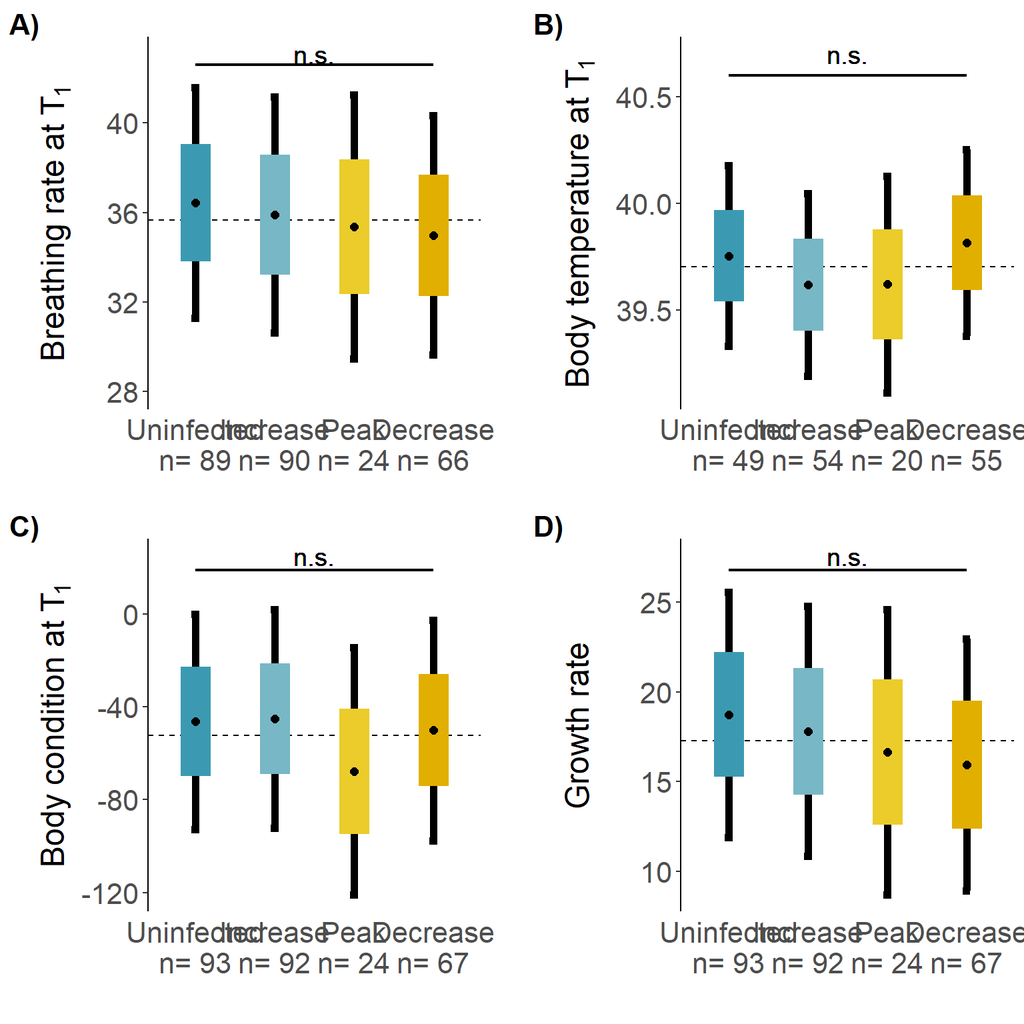

```r
figS1 <- Fig_S1A + Fig_S1B + Fig_S1C2 + Fig_S1D + plot_annotation(tag_levels = "A",
    tag_suffix = ")") & theme(plot.tag = element_text(size = 16, face = "bold"))
figS1
```

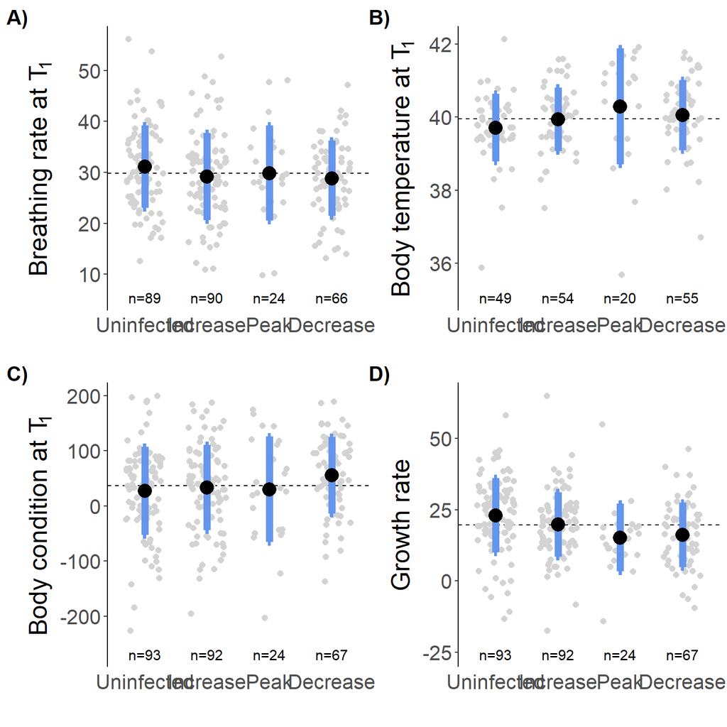

```r
## Plotting observed values across infection stages
## -----------------------------------------------------------------------------

ggsave(figS1, filename = "./Figs/FigS1_predicted_physio_param_infection_stages.png",
    units = "px", width = 3700, height = 3700)


Fig_S2A = ggplot(df[!df$Diff_Inf_Class %in% NA, ]) + aes(Diff_Inf_Class, Breathing_rate) +
    geom_hline(yintercept = mean(df$Breathing_rate, na.rm = T), linetype = "dashed") +
    labs(x = "", y = bquote("Breathing rate at T"[1])) + geom_jitter(color = "lightgrey",
    size = 2, width = 0.3) + stat_summary(fun = mean, colour = "cornflowerblue",
    geom = "errorbar", size = 2.8, width = 0.05, show.legend = FALSE, fun.max = function(x) mean(x) +
        sd(x), fun.min = function(x) mean(x) - sd(x)) + stat_summary(fun = mean,
    colour = "black", geom = "point", size = 5, show.legend = FALSE) + stat_n_text() +
    theme_classic() + theme(legend.position = "none", axis.title = element_text(size = 20),
    axis.text = element_text(size = 16), axis.line.x = element_blank(), axis.ticks.x = element_blank(),
    plot.margin = margin(0, 0, 0, 0, "cm"), plot.title = element_text(hjust = 0.5,
        face = "bold"))

Fig_S2B = ggplot(df[!df$Diff_Inf_Class %in% NA, ]) + aes(Diff_Inf_Class, body_temperature) +
    geom_hline(yintercept = mean(df$body_temperature, na.rm = T), linetype = "dashed") +
    labs(x = "", y = bquote("Body temperature at T"[1])) + geom_jitter(color = "lightgrey",
    size = 2, width = 0.3) + stat_summary(fun = mean, colour = "cornflowerblue",
    geom = "errorbar", size = 2.8, width = 0.05, show.legend = FALSE, fun.max = function(x) mean(x) +
        sd(x), fun.min = function(x) mean(x) - sd(x)) + stat_summary(fun = mean,
    colour = "black", geom = "point", size = 5, show.legend = FALSE) + stat_n_text() +
    theme_classic() + theme(legend.position = "none", axis.title = element_text(size = 20),
    axis.text = element_text(size = 16), axis.line.x = element_blank(), axis.ticks.x = element_blank(),
    plot.margin = margin(0, 0, 0, 0, "cm"), plot.title = element_text(hjust = 0.5,
        face = "bold"))

Fig_S2C = ggplot(df[!df$Diff_Inf_Class %in% NA, ]) + aes(Diff_Inf_Class, body_condition.2) +
    geom_hline(yintercept = mean(df$body_condition.2, na.rm = T), linetype = "dashed") +
    labs(x = "", y = bquote("Body condition at T"[1])) + geom_jitter(color = "lightgrey",
    size = 2, width = 0.3) + stat_summary(fun = mean, colour = "cornflowerblue",
    geom = "errorbar", size = 2.8, width = 0.05, show.legend = FALSE, fun.max = function(x) mean(x) +
        sd(x), fun.min = function(x) mean(x) - sd(x)) + stat_summary(fun = mean,
    colour = "black", geom = "point", size = 5, show.legend = FALSE) + stat_n_text() +
    theme_classic() + theme(legend.position = "none", axis.title = element_text(size = 20),
    axis.text = element_text(size = 16), axis.line.x = element_blank(), axis.ticks.x = element_blank(),
    plot.margin = margin(0, 0, 0, 0, "cm"), plot.title = element_text(hjust = 0.5,
        face = "bold"))

Fig_S2D = ggplot(df[!df$Diff_Inf_Class %in% NA, ]) + aes(Diff_Inf_Class, Growth_rate) +
    geom_hline(yintercept = mean(df$Growth_rate, na.rm = T), linetype = "dashed") +
    labs(x = "", y = "Growth rate") + geom_jitter(color = "lightgrey", size = 2,
    width = 0.3) + stat_summary(fun = mean, colour = "cornflowerblue", geom = "errorbar",
    size = 2.8, width = 0.05, show.legend = FALSE, fun.max = function(x) mean(x) +
        sd(x), fun.min = function(x) mean(x) - sd(x)) + stat_summary(fun = mean,
    colour = "black", geom = "point", size = 5, show.legend = FALSE) + stat_n_text() +
    theme_classic() + theme(legend.position = "none", axis.title = element_text(size = 20),
    axis.text = element_text(size = 16), axis.line.x = element_blank(), axis.ticks.x = element_blank(),
    plot.margin = margin(0, 0, 0, 0, "cm"), plot.title = element_text(hjust = 0.5,
        face = "bold"))

## Saving Figure S2
## -----------------------------------------------------------------------------
figs2 = Fig_S2A + Fig_S2B + Fig_S2C + Fig_S2D + plot_annotation(tag_levels = "A",
    tag_suffix = ")") & theme(plot.tag = element_text(size = 16, face = "bold"))
figs2
```

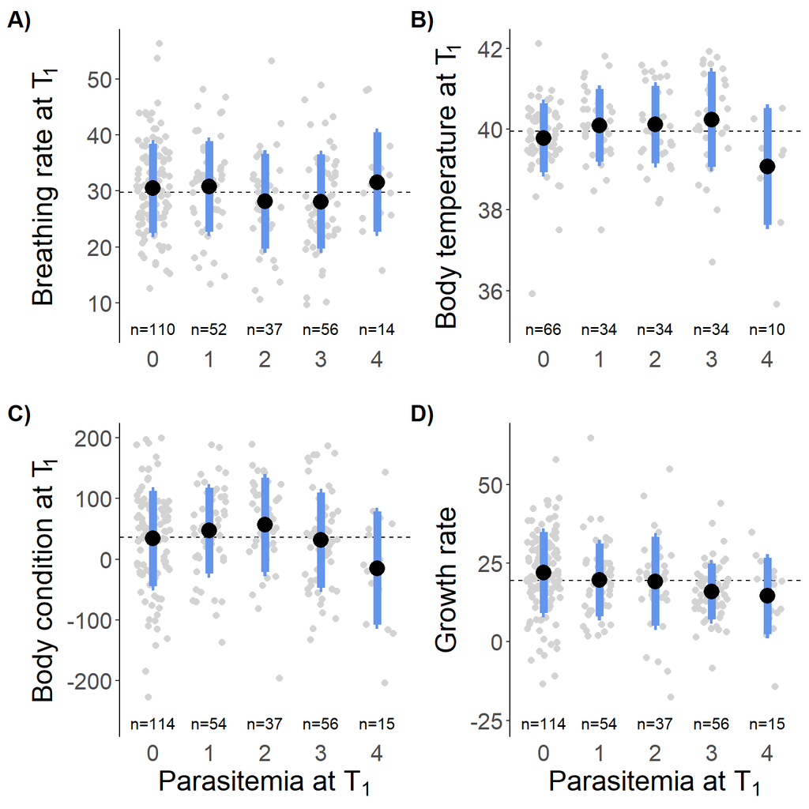

```r
ggsave(figs2, filename = "./Figs/FigS2_observed_physio_param_infection_stages.png",
    units = "px", width = 3500, height = 3800)

## Plotting observed values across infection intensities
## -----------------------------------------------------------------------------
Fig_S3A = ggplot(df[!df$Infection_intensity.2 %in% NA, ]) + aes(Infection_intensity.2,
    Breathing_rate) + geom_hline(yintercept = mean(df$Breathing_rate, na.rm = T),
    linetype = "dashed") + labs(x = "", y = bquote("Breathing rate at T"[1])) + geom_jitter(color = "lightgrey",
    size = 2, width = 0.3) + stat_summary(fun = mean, colour = "cornflowerblue",
    geom = "errorbar", size = 2.8, width = 0.05, show.legend = FALSE, fun.max = function(x) mean(x) +
        sd(x), fun.min = function(x) mean(x) - sd(x)) + stat_summary(fun = mean,
    colour = "black", geom = "point", size = 5, show.legend = FALSE) + stat_n_text() +
    theme_classic() + theme(legend.position = "none", axis.title = element_text(size = 20),
    axis.text = element_text(size = 16), axis.line.x = element_blank(), axis.ticks.x = element_blank(),
    plot.margin = margin(0, 0, 0, 0, "cm"), plot.title = element_text(hjust = 0.5,
        face = "bold"))

Fig_S3B <- ggplot(df[!df$Infection_intensity.2 %in% NA, ]) + aes(Infection_intensity.2,
    body_temperature) + geom_hline(yintercept = mean(df$body_temperature, na.rm = T),
    linetype = "dashed") + labs(x = "", y = bquote("Body temperature at T"[1])) +
    geom_jitter(color = "lightgrey", size = 2, width = 0.3) + stat_summary(fun = mean,
    colour = "cornflowerblue", geom = "errorbar", size = 2.8, width = 0.05, show.legend = FALSE,
    fun.max = function(x) mean(x) + sd(x), fun.min = function(x) mean(x) - sd(x)) +
    stat_summary(fun = mean, colour = "black", geom = "point", size = 5, show.legend = FALSE) +
    stat_n_text() + theme_classic() + theme(legend.position = "none", axis.title = element_text(size = 20),
    axis.text = element_text(size = 16), axis.line.x = element_blank(), axis.ticks.x = element_blank(),
    plot.margin = margin(0, 0, 0, 0, "cm"), plot.title = element_text(hjust = 0.5,
        face = "bold"))

Fig_S3C = ggplot(df[!df$Infection_intensity.2 %in% NA, ]) + aes(Infection_intensity.2,
    body_condition.2) + geom_hline(yintercept = mean(df$body_condition.2, na.rm = T),
    linetype = "dashed") + labs(x = bquote("Parasitemia at T"[1]), y = bquote("Body condition at T"[1])) +
    geom_jitter(color = "lightgrey", size = 2, width = 0.3) + stat_summary(fun = mean,
    colour = "cornflowerblue", geom = "errorbar", size = 2.8, width = 0.05, show.legend = FALSE,
    fun.max = function(x) mean(x) + sd(x), fun.min = function(x) mean(x) - sd(x)) +
    stat_summary(fun = mean, colour = "black", geom = "point", size = 5, show.legend = FALSE) +
    stat_n_text() + theme_classic() + theme(legend.position = "none", axis.title = element_text(size = 20),
    axis.text = element_text(size = 16), axis.line.x = element_blank(), axis.ticks.x = element_blank(),
    plot.margin = margin(0, 0, 0, 0, "cm"), plot.title = element_text(hjust = 0.5,
        face = "bold"))

Fig_S3D = ggplot(df[!df$Infection_intensity.2 %in% NA, ]) + aes(Infection_intensity.2,
    Growth_rate) + geom_hline(yintercept = mean(df$Growth_rate, na.rm = T), linetype = "dashed") +
    labs(x = bquote("Parasitemia at T"[1]), y = "Growth rate") + geom_jitter(color = "lightgrey",
    size = 2, width = 0.3) + stat_summary(fun = mean, colour = "cornflowerblue",
    geom = "errorbar", size = 2.8, width = 0.05, show.legend = FALSE, fun.max = function(x) mean(x) +
        sd(x), fun.min = function(x) mean(x) - sd(x)) + stat_summary(fun = mean,
    colour = "black", geom = "point", size = 5, show.legend = FALSE) + stat_n_text() +
    theme_classic() + theme(legend.position = "none", axis.title = element_text(size = 20),
    axis.text = element_text(size = 16), axis.line.x = element_blank(), axis.ticks.x = element_blank(),
    plot.margin = margin(0, 0, 0, 0, "cm"), plot.title = element_text(hjust = 0.5,
        face = "bold"))

## Saving figure S3
## -----------------------------------------------------------------------------
figs3 = Fig_S3A + Fig_S3B + Fig_S3C + Fig_S3D + plot_annotation(tag_levels = "A",
    tag_suffix = ")") & theme(plot.tag = element_text(size = 16, face = "bold"))
figs3
```

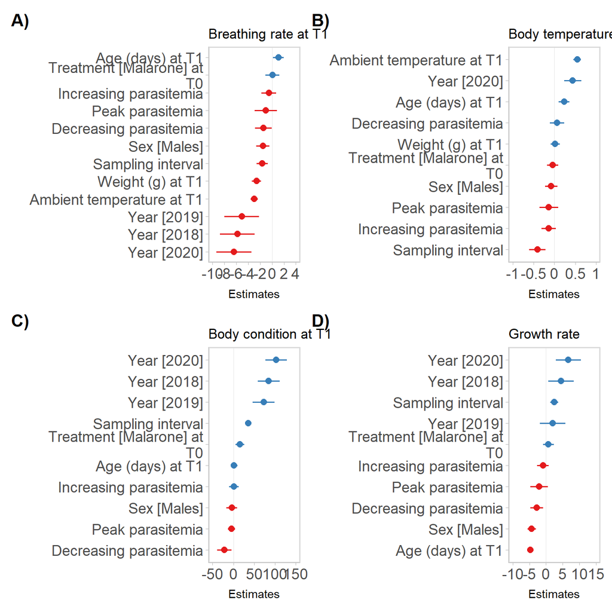

```r
ggsave(figs3, filename = "./Figs/FigS3_observed_physio_param_infection_intensities.png",
    units = "px", width = 3500, height = 3800)

## Plotting effect sizes of 'infection stages' models
## -----------------------------------------------------------------------------
Fig_S4A = plot_model(lmer_br, sort.est = T, se = T, title = "Breathing rate at T1",
    axis.labels = rev(c("Age (days) at T1", "Treatment [Malarone] at T0", "Increasing parasitemia",
        "Peak parasitemia", "Decreasing parasitemia", "Sex [Males]", "Sampling interval",
        "Weight (g) at T1", "Ambient temperature at T1", "Year [2019]", "Year [2018]",
        "Year [2020]")))

Fig_S4B = plot_model(lmer_bt, sort.est = T, se = T, title = "Body temperature at T1",
    axis.labels = rev(c("Ambient temperature at T1", "Year [2020]", "Age (days) at T1",
        "Decreasing parasitemia", "Weight (g) at T1", "Treatment [Malarone] at T0",
        "Sex [Males]", "Peak parasitemia", "Increasing parasitemia", "Sampling interval")))

Fig_S4C = plot_model(lmer_bc2, sort.est = T, se = T, title = "Body condition at T1",
    axis.labels = rev(c("Year [2020]", "Year [2018]", "Year [2019]", "Sampling interval",
        "Treatment [Malarone] at T0", "Age (days) at T1", "Increasing parasitemia",
        "Sex [Males]", "Peak parasitemia", "Decreasing parasitemia")))

Fig_S4D = plot_model(lmer_gr, sort.est = T, se = T, title = "Growth rate", axis.labels = rev(c("Year [2020]",
    "Year [2018]", "Sampling interval", "Year [2019]", "Treatment [Malarone] at T0",
    "Increasing parasitemia", "Peak parasitemia", "Decreasing parasitemia", "Sex [Males]",
    "Age (days) at T1")))

## Saving Figure S4
## -----------------------------------------------------------------------------
figs4 = Fig_S4A + Fig_S4B + Fig_S4C + Fig_S4D + plot_annotation(tag_levels = "A",
    tag_suffix = ")") & theme(axis.text = element_text(size = 14), plot.tag = element_text(size = 16,
    face = "bold"))
figs4
```

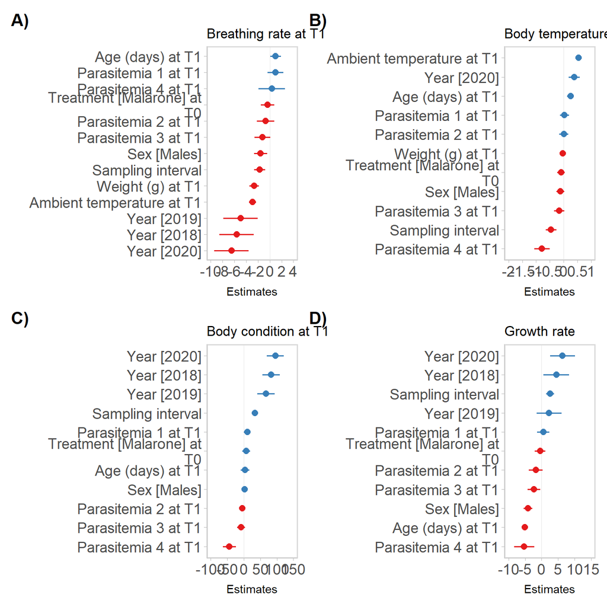

```r
ggsave(figs4, filename = "./Figs/FigS4_effect_sizes_param_infection_stages.png",
    units = "px", width = 3500, height = 3800)

## Plotting effect sizes of 'infection intensities' models
## -----------------------------------------------------------------------------
Fig_S5A = plot_model(lmer_br_para, sort.est = T, se = T, title = "Breathing rate at T1",
    axis.labels = rev(c("Age (days) at T1", "Parasitemia 1 at T1", "Parasitemia 4 at T1",
        "Treatment [Malarone] at T0", "Parasitemia 2 at T1", "Parasitemia 3 at T1",
        "Sex [Males]", "Sampling interval", "Weight (g) at T1", "Ambient temperature at T1",
        "Year [2019]", "Year [2018]", "Year [2020]")))

Fig_S5B = plot_model(lmer_bt_para, sort.est = T, se = T, title = "Body temperature at T1",
    axis.labels = rev(c("Ambient temperature at T1", "Year [2020]", "Age (days) at T1",
        "Parasitemia 1 at T1", "Parasitemia 2 at T1", "Weight (g) at T1", "Treatment [Malarone] at T0",
        "Sex [Males]", "Parasitemia 3 at T1", "Sampling interval", "Parasitemia 4 at T1")))

Fig_S5C = plot_model(lmer_bc_para2, sort.est = T, se = T, title = "Body condition at T1",
    axis.labels = rev(c("Year [2020]", "Year [2018]", "Year [2019]", "Sampling interval",
        "Parasitemia 1 at T1", "Treatment [Malarone] at T0", "Age (days) at T1",
        "Sex [Males]", "Parasitemia 2 at T1", "Parasitemia 3 at T1", "Parasitemia 4 at T1")))

Fig_S5D = plot_model(lmer_gr_para, sort.est = T, se = T, title = "Growth rate", axis.labels = rev(c("Year [2020]",
    "Year [2018]", "Sampling interval", "Year [2019]", "Parasitemia 1 at T1", "Treatment [Malarone] at T0",
    "Parasitemia 2 at T1", "Parasitemia 3 at T1", "Sex [Males]", "Age (days) at T1",
    "Parasitemia 4 at T1")))

## Figure S5: effect sizes for infection intensity models
## -----------------------------------------------------------------------------
figs5 = Fig_S5A + Fig_S5B + Fig_S5C + Fig_S5D + plot_annotation(tag_levels = "A",
    tag_suffix = ")") & theme(axis.text = element_text(size = 14), plot.tag = element_text(size = 16,
    face = "bold"))
figs5
```

```r
ggsave(figs5, filename = "./Figs/FigS5_effect_sizes_param_infection_intensities.png",
    units = "px", width = 3500, height = 3800)
```

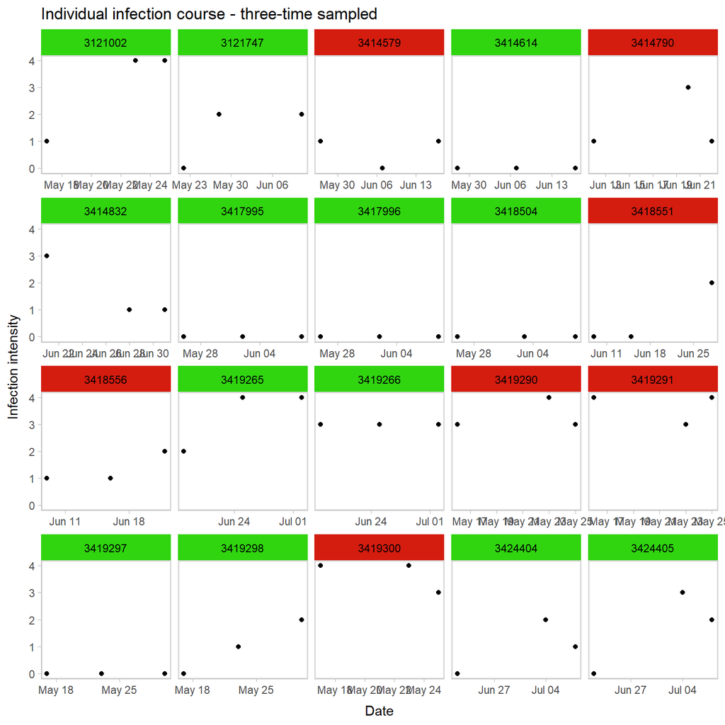

```r
## Robustness infection stages - summary graph of third sampled individuals
##------------------------------------------------------------------------------

# Loading the dataset

third_sampled = readxl::read_excel("third_samples_indidividuals.xlsx")

# Computing the number of days between second and third sampling

third_sampled$Avg_third = third_sampled$Date.3 - third_sampled$Date.2

# Categorizing infection trends

third_sampled$Stage.1_2 = as.numeric(third_sampled$Infection_intensity.2) - as.numeric(third_sampled$Infection_intensity.1)

third_sampled$Stage.2_3 = as.numeric(third_sampled$Infection_intensity.3) - as.numeric(third_sampled$Infection_intensity.1)

third_sampled$comp_inf_stages = NA

for (i in 1:length(third_sampled$Date.1)) {
    # cat(third_sampled$Stage.1_2[i], 'versus', third_sampled$Stage.2_3[i],
    # '\n')
    if (third_sampled$Infection_intensity.1[i] == 0 & third_sampled$Infection_intensity.2[i] ==
        0 & third_sampled$Infection_intensity.3[i] == 0) {
        third_sampled$comp_inf_stages[i] = "Unchanged_uninfected"
        next
    }
    if (third_sampled$Stage.1_2[i] > 0 & third_sampled$Stage.1_2[i] == third_sampled$Stage.2_3[i]) {
        third_sampled$comp_inf_stages[i] = "Unchanged_increase"
        next
    }
    if (third_sampled$Stage.1_2[i] < 0 & third_sampled$Stage.1_2[i] == third_sampled$Stage.2_3[i]) {
        third_sampled$comp_inf_stages[i] = "Unchanged_decrease"
        next
    }
    if (third_sampled$Stage.1_2[i] == 0 & third_sampled$Stage.1_2[i] == third_sampled$Stage.2_3[i]) {
        third_sampled$comp_inf_stages[i] = "Unchanged_stable"
        next
    }
    if (third_sampled$Stage.1_2[i] < 0 & third_sampled$Stage.2_3[i] > 0) {
        third_sampled$comp_inf_stages[i] = "Decrease_to_Increase"
        next
    }
    if (third_sampled$Stage.1_2[i] < 0 & third_sampled$Stage.2_3[i] == 0) {
        third_sampled$comp_inf_stages[i] = "Decrease_to_Stable"
        next
    }
    if (third_sampled$Stage.1_2[i] == 0 & third_sampled$Stage.2_3[i] < 0) {
        third_sampled$comp_inf_stages[i] = "Stable_to_Decrease"
        next
    }
    if (third_sampled$Stage.1_2[i] == 0 & third_sampled$Stage.2_3[i] > 0) {
        third_sampled$comp_inf_stages[i] = "Stable_to_Increase"
        next
    }
    if (third_sampled$Stage.1_2[i] > 0 & third_sampled$Stage.2_3[i] < 0) {
        third_sampled$comp_inf_stages[i] = "Increase_to_decrease"
        next
    }
    if (third_sampled$Stage.1_2[i] > 0 & third_sampled$Stage.2_3[i] == 0) {
        third_sampled$comp_inf_stages[i] = "Increase_to_stable"
        next
    }
    if (third_sampled$Stage.1_2[i] > 0 & third_sampled$Stage.2_3[i] > 0) {
        third_sampled$comp_inf_stages[i] = "Unchanged_increase"
        next
    }
}

third_sampled$comp_inf_stages_summary = ifelse(third_sampled$comp_inf_stages %in%
    c("Unchanged_increase", "Unchanged_decrease", "Unchanged_stable", "Unchanged_uninfected"),
    "Unchanged", "Differed")

# Plotting infection intensity across three sampling

strip = strip_themed(background_x = elem_list_rect(fill = ifelse(third_sampled$comp_inf_stages_summary %in%
    "Unchanged", "#30D40F", "#D41C0F")))

gg_trends = ggplot(third_sampled) + geom_point(aes(Date.1, Infection_intensity.1)) +
    geom_point(aes(Date.2, Infection_intensity.2)) + geom_point(aes(Date.3, Infection_intensity.3)) +
    facet_wrap2(~`Ring no`, scales = "free_x", strip = strip) + labs(title = "Individual infection course - three-time sampled",
    x = "Date", y = "Infection intensity")

gg_trends
```

```r
## Figure S6: Infection course - third sampled individuals
##------------------------------------------------------------------------------

ggsave(gg_trends, filename = "./Figs/FigS6_infection_trends_third_sampled.png", units = "px",
    width = 3700, height = 1700)
```

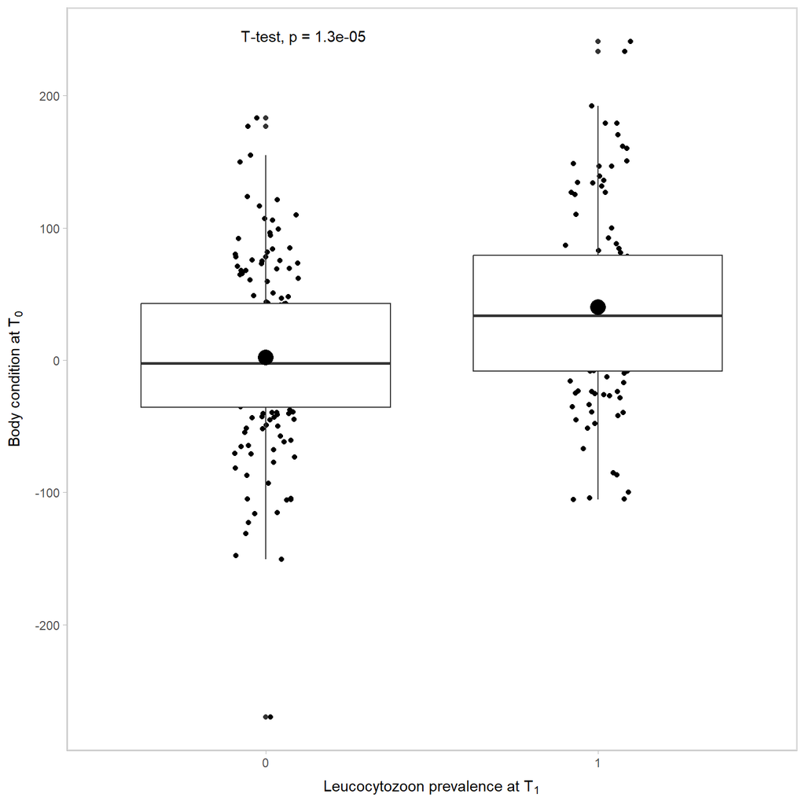

```r
## Figure S7: body condition at first sampling according to L. prevalence
##------------------------------------------------------------------------------

figs7 = ggplot(df) + aes(Prevalence1, body_condition.1) + geom_jitter(width = 0.1) +
    geom_boxplot() + stat_summary(fun = mean, colour = "black", geom = "point", size = 5,
    show.legend = FALSE) + labs(x = bquote("Leucocytozoon prevalence at T"[1]), y = bquote("Body condition at T"[0])) +
    stat_compare_means(method = "t.test")

figs7
```

```r
ggsave(figs7, filename = "./Figs/FigS7_body_condition_T1_to_prevalence.png", units = "px",
    width = 3700, height = 3700)
```

## Estimating measurement error of body temperature

```r
## Loading repeated temperature measures
## -----------------------------------------------------------------------------
rTemp = read.csv2("./Repeatability_temperatures.csv", h = T, dec = ".") %>%
    mutate(ID = as.factor(ID)) %>%
    mutate(Date = as.Date(Date, format = "%d/%m/%y")) %>%
    mutate(Repeat = as.factor(Repeat))

## Estimating repeatability of paired measures
## -----------------------------------------------------------------------------
rpt(Temperature ~ (1 | ID), grname = "ID", data = rTemp, npermut = 1000, datatype = "Gaussian")
```

```
#> Bootstrap Progress:
#> Permutation Progress for ID :
#>
#>
#> Repeatability estimation using the lmm method
#>
#> Repeatability for ID
#> R  = 0.906
#> SE = 0.037
#> CI = [0.805, 0.951]
#> P  = 5.47e-14 [LRT]
#>      0.001 [Permutation]
## Estimating the variance of error
## -----------------------------------------------------------------------------
```

```r
rt = ddply(rTemp, .(ID), summarize, mean = mean(Temperature), sd = sd(Temperature))

## Values of mean and standard deviation of average paired body temperatures
## -----------------------------------------------------------------------------
mean(rt$mean)
```

```
#> [1] 40.3466
```

```r
mean(rt$sd)
```

```
#> [1] 0.3968169
```